# Business Forecasting for fish production in United States

Vallabh Sawant, Gaurav Vishwakarma, Rakshit Karkera

```r
rm(list = ls())
library(fpp)
library(readxl)
library(TTR)
library(xts)
FP_US <- read_excel("Fish_Production_UnitedStates.xlsx")
head(FP_US)
```

```
## # A tibble: 6 x 4
##   Entity        Code   Year `Capture fisheries production (metric tons)`
##   <chr>         <chr> <dbl>                                        <dbl>
## 1 United States USA    1960                                      2714623
## 2 United States USA    1961                                      2852004
## 3 United States USA    1962                                      2897963
## 4 United States USA    1963                                      2655052
## 5 United States USA    1964                                      2519951
## 6 United States USA    1965                                      2649980
```

```r
summary(FP_US)
```

```
##     Entity              Code                Year
##  Length:57          Length:57          Min.   :1960
##  Class :character   Class :character   1st Qu.:1974
##  Mode  :character   Mode  :character   Median :1988
##                                        Mean   :1988
##                                        3rd Qu.:2002
##                                        Max.   :2016
##  Capture fisheries production (metric tons)
##  Min.   :2311726
##  1st Qu.:2885967
##  Median :4721775
##  Mean   :4171508
##  3rd Qu.:5045443
##  Max.   :5694242
```

```r
FP_US_TS <- ts(FP_US$`Capture fisheries production (metric tons)`, start = c(1960))
#FP_US_TS
#class(FP_US_TS)
summary(FP_US_TS)
```

```
##    Min. 1st Qu.  Median    Mean 3rd Qu.    Max.
## 2311726 2885967 4721775 4171508 5045443 5694242
```

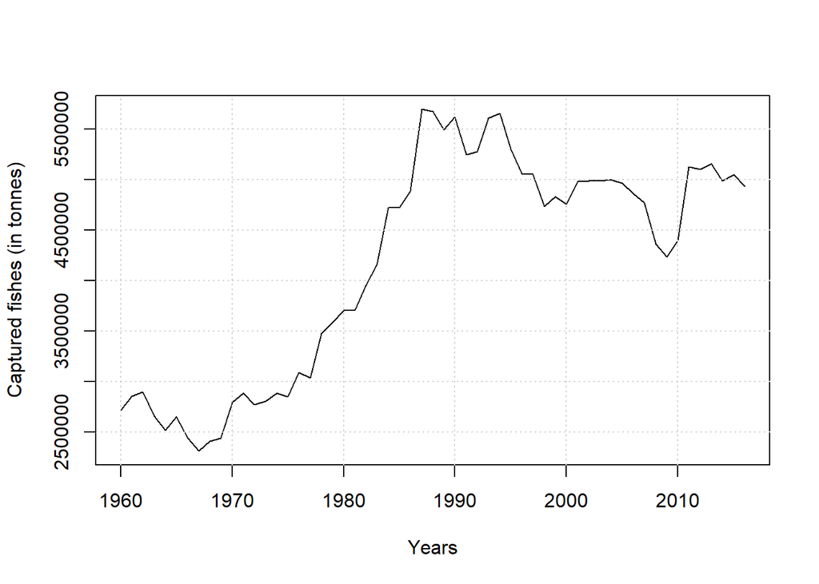

```r
plot(FP_US_TS, xlab = "Years", ylab = "Captured fishes (in tonnes)")
grid(nx=NULL, ny=NULL)
```

#The time series shows trend but no seasionality. Also, in the above plot, we can see a sudden rise and the data then gets stable after 1988. Thus we can ignore the previous years and consider the data form 1988 for our forecast.

```r
FP_US_TS_recent = window(FP_US_TS,start = c(1988))
summary(FP_US_TS_recent)
```

```
##    Min. 1st Qu.  Median    Mean 3rd Qu.    Max.
## 4233804 4858805 4995418 5040506 5244569 5670666
```

#The summary shows that the mean has moved more on the higher side since we chose a different window.

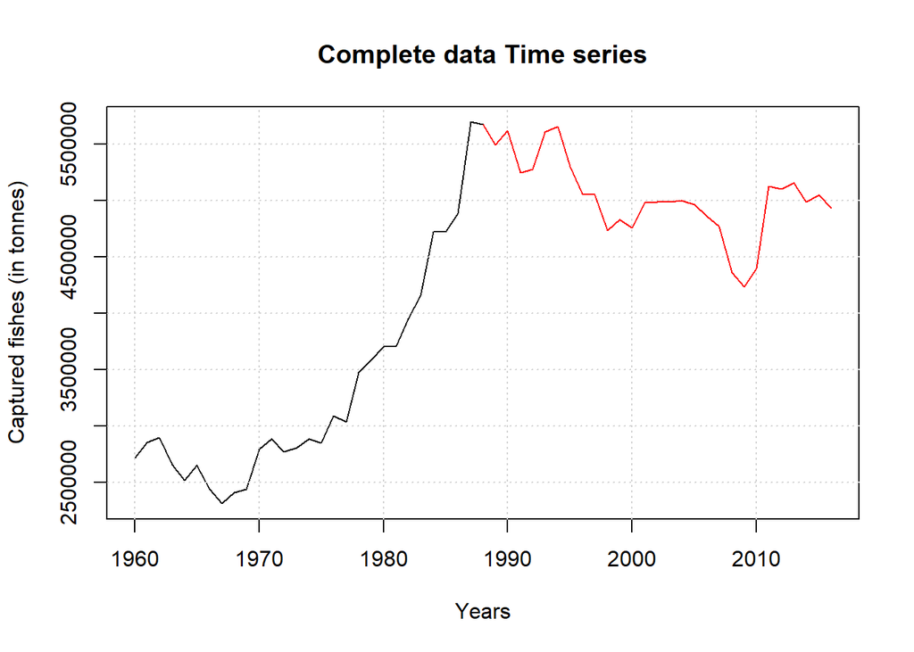

```r
plot(FP_US_TS, xlab = "Years", ylab = "Captured fishes (in tonnes)", main = "Complete data Time series")
grid(nx=NULL, ny=NULL)
lines(FP_US_TS_recent, col = "Red")
```

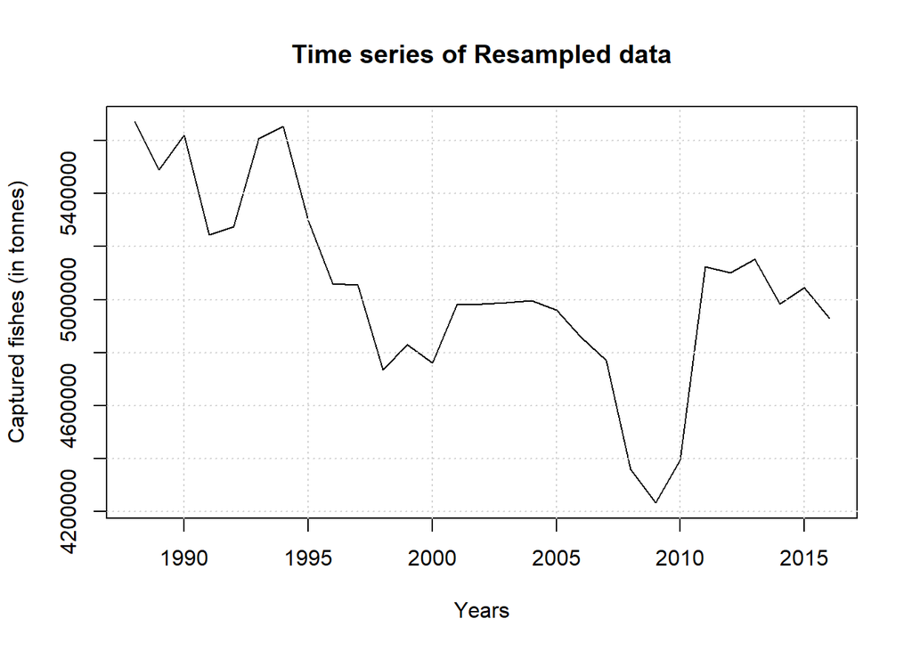

```r
plot(FP_US_TS_recent, xlab = "Years", ylab = "Captured fishes (in tonnes)", main = "Time series of Resampled data")
grid(nx=NULL, ny=NULL)
```

#Looking at the plot, we can come to a conclusion that the data shows no seasonality. It does show some trend.

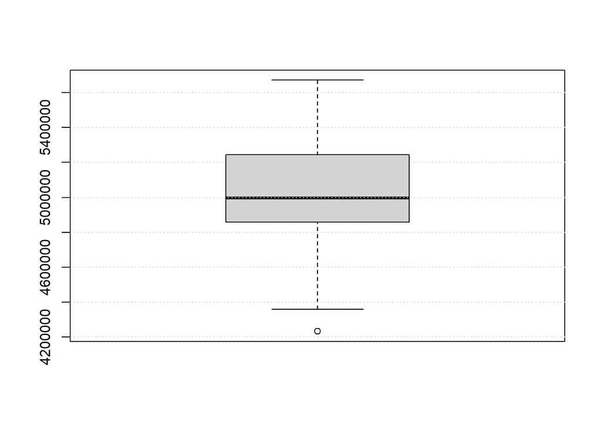

```r
boxplot(FP_US_TS_recent)
grid(nx=NA, ny=NULL)
```

#As stated in the summary, the boxplot confirms the mean is around 5000000 with an outlier. The 1st quartile is 4858805 where as 3rd quartile is at 5244569. The median is at 4995418 and the mean is 5040506.

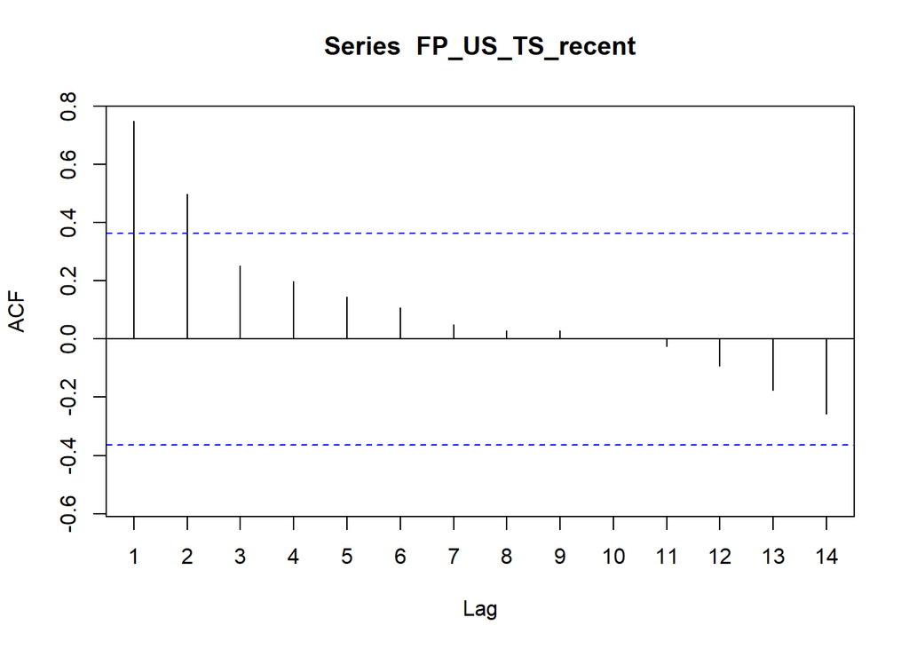

```r
Acf(FP_US_TS_recent)
```

#The Acf shows heavy correlation between the current and the previous point as it is shown in the plot above.

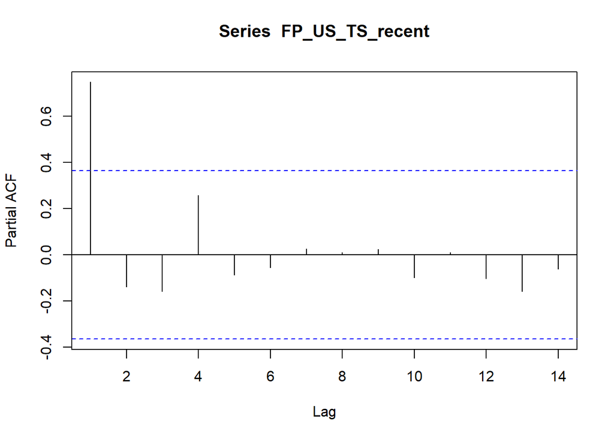

```r
pacf(FP_US_TS_recent)
```

#The pacf also shows significant correlation between the current and the previous point.

```r
attributes(FP_US_TS_recent)
```

```
## $tsp
## [1] 1988 2016    1
##
## $class
## [1] "ts"
```

#Naive start

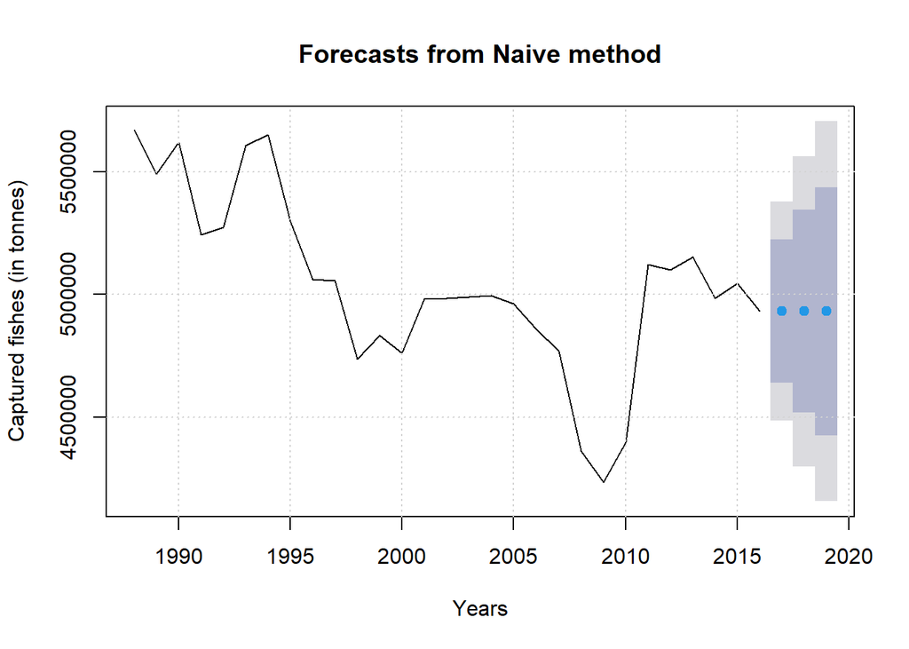

```r
naive_forecast = naive(FP_US_TS_recent,3)
plot(naive_forecast, xlab = "Years", ylab = "Captured fishes (in tonnes)")
grid(nx=NULL, ny=NULL)
```

#The above is the plot of naive model. This model basically considers the previous values and forecasts on the basis of that. Snaive won’t be present because the data is not seasonal. So technically, it will work as a naive model.

```r
attributes(naive_forecast)
```

```
## $names
##  [1] "method"    "model"     "lambda"    "x"         "fitted"    "residuals"
##  [7] "series"    "mean"      "level"     "lower"     "upper"
##
## $class
## [1] "forecast"
```

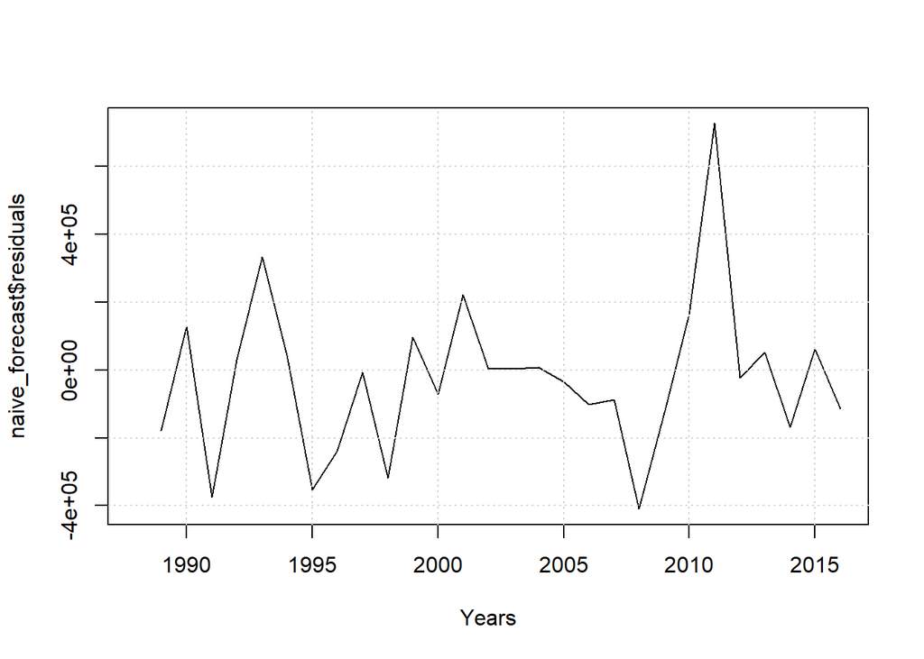

```r
plot(naive_forecast$residuals, xlab = "Years")
grid(nx=NULL, ny=NULL)
```

#Here we don’t see a pattern in the graph. This is a good sign. The residuals are scattered randomly.

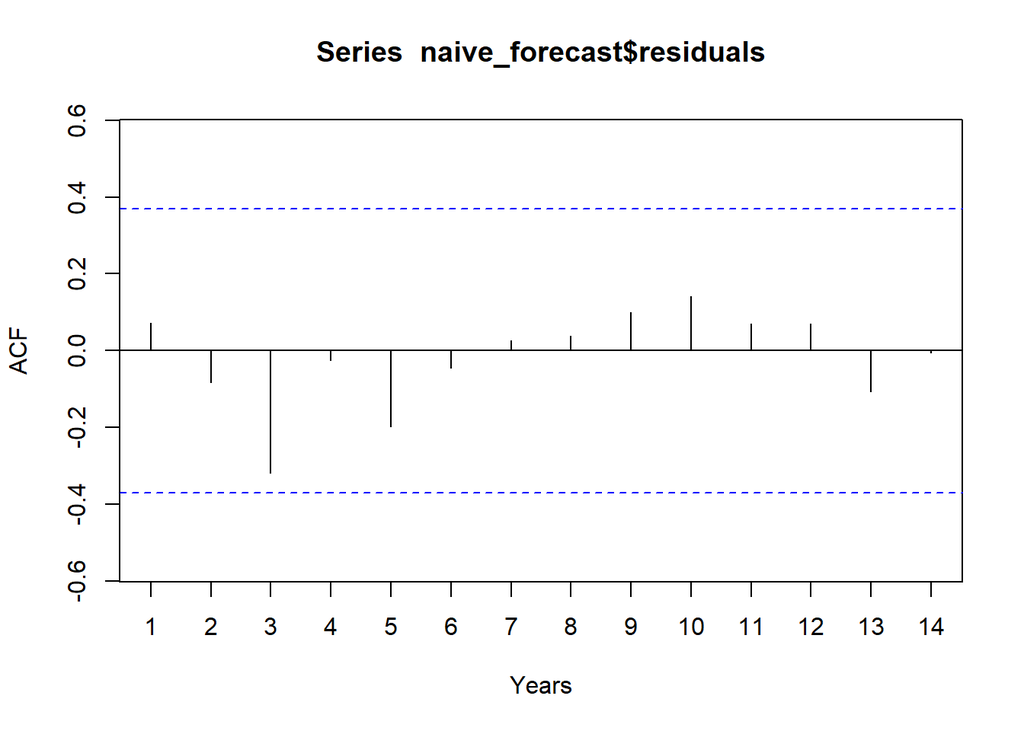

```r
Acf(naive_forecast$residuals, xlab = "Years")
```

#Acf shows no correlation between the residuals. This is ideal.

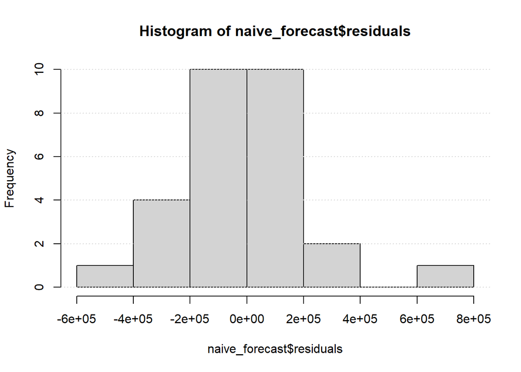

```r
hist(naive_forecast$residuals)
grid(nx=NA, ny=NULL)
```

#The residuals seem a bit right skewed. Since most of the residuals are around the mean that is 0, it seems good.

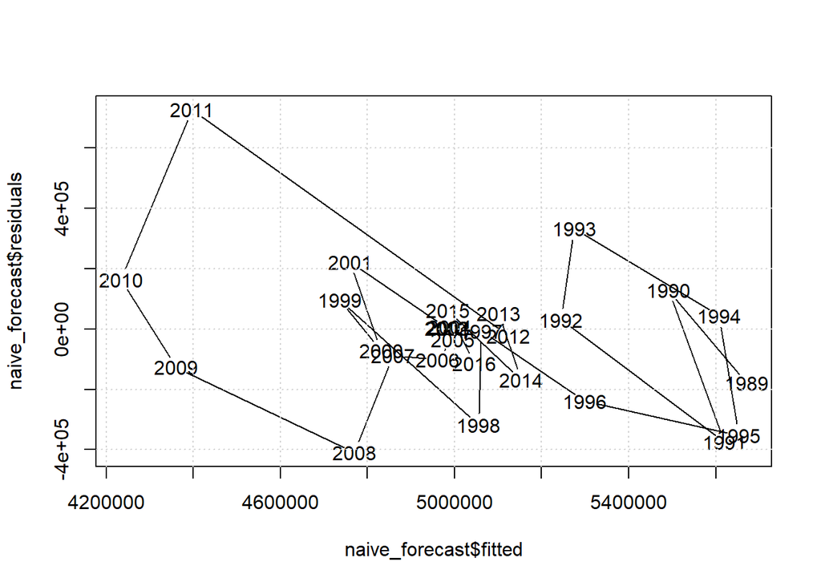

```r
plot(naive_forecast$fitted,naive_forecast$residuals)
grid(nx=NULL, ny=NULL)
```

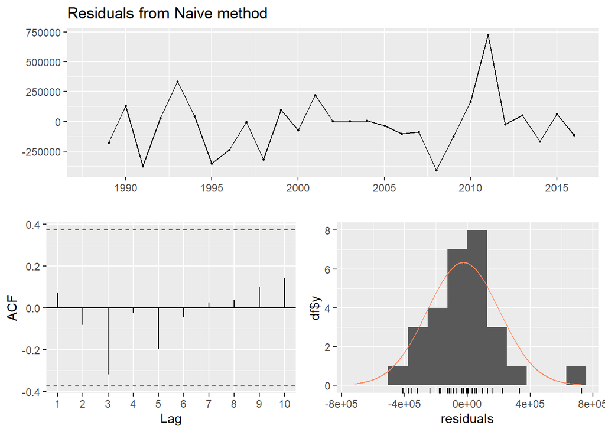

```
##
##  Ljung-Box test
##
## data:  Residuals from Naive method
## Q* = 5.3312, df = 6, p-value = 0.5021
##
## Model df: 0.   Total lags used: 6
```

```r
checkresiduals(naive_forecast)
```

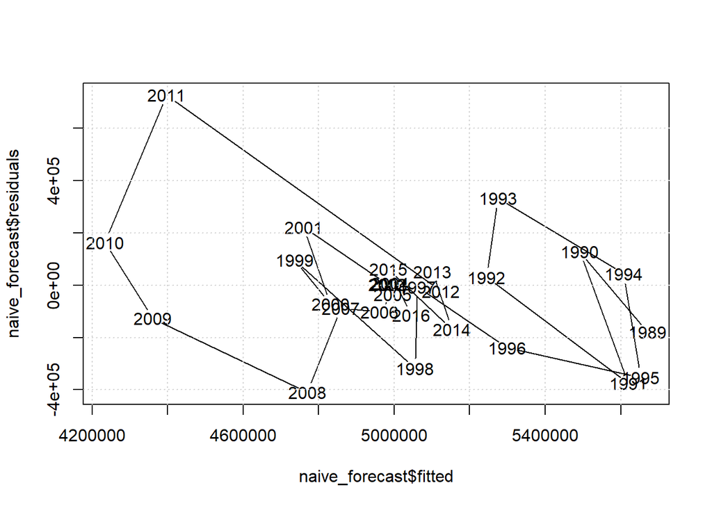

```r
plot(naive_forecast$fitted,naive_forecast$residuals)
grid(nx=NULL, ny=NULL)
```

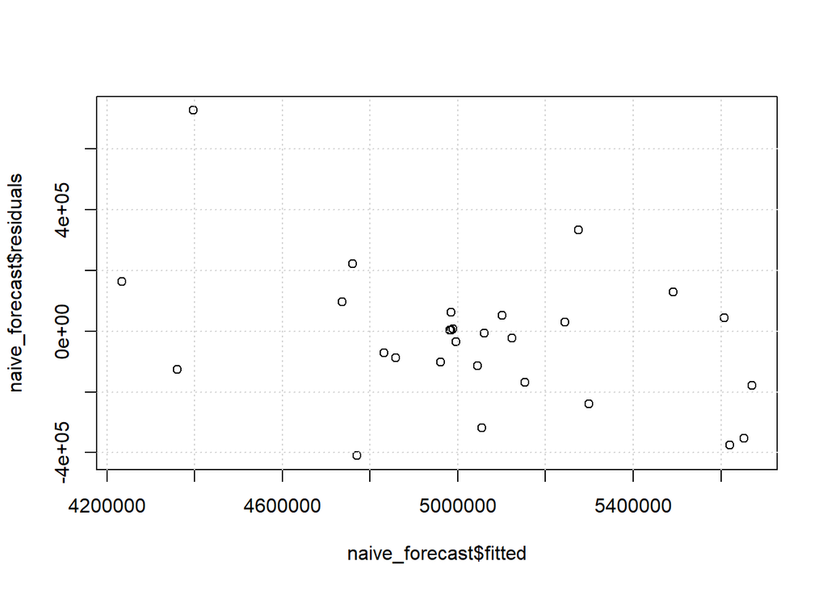

```r
plot.ts(naive_forecast$fitted,naive_forecast$residuals,xy.labels = FALSE,xy.lines = FALSE)
grid(nx=NULL, ny=NULL)
```

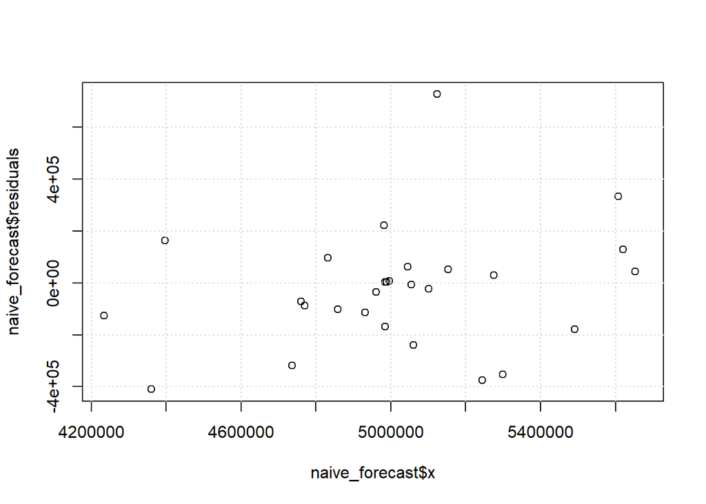

```r
plot.ts(naive_forecast$x,naive_forecast$residuals,xy.labels = FALSE,xy.lines = FALSE)
grid(nx=NULL, ny=NULL)
```

#Here we don’t see a pattern in the graph. This is a good sign. The residuals are scattered randomly.

```r
accuracy(naive_forecast)
```

```
##                     ME     RMSE      MAE        MPE     MAPE MASE       ACF1
## Training set -26416.04 228140.4 160037.6 -0.6049683 3.205752    1 0.07203671
```

```r
forecast(naive_forecast,h=3)
```

```
##      Point Forecast   Lo 80   Hi 80   Lo 95   Hi 95
## 2017        4931017 4638643 5223391 4483870 5378164
## 2018        4931017 4517538 5344496 4298656 5563378
## 2019        4931017 4424611 5437423 4156536 5705498
```

#Naive end

#SMA start

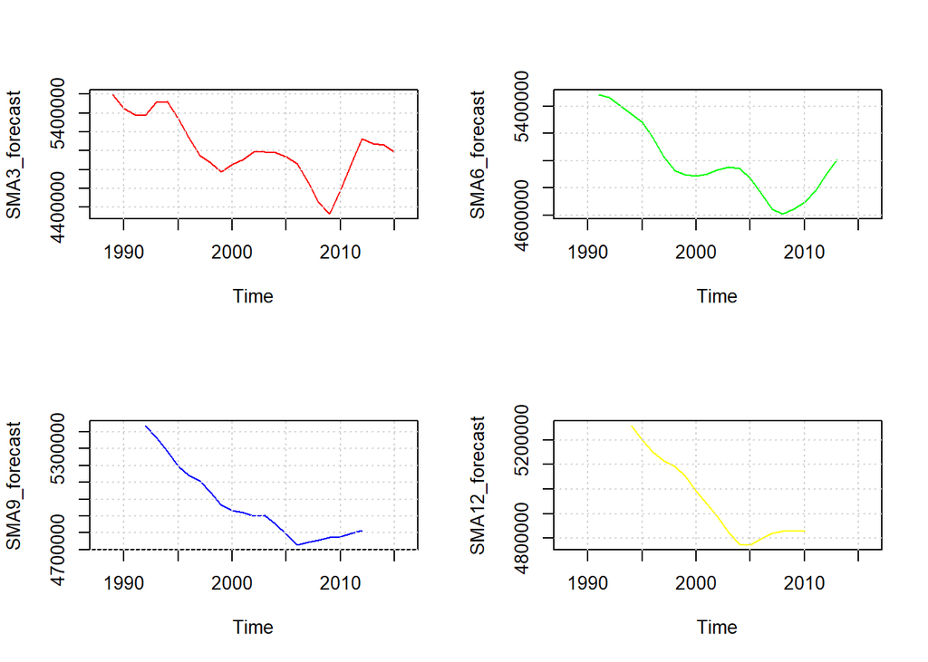

```r
par(mfrow=c(2,2))
SMA3_forecast <- ma(FP_US_TS_recent,order = 3)
plot(SMA3_forecast, col = "Red")
grid(nx=NULL, ny=NULL)
SMA6_forecast <- ma(FP_US_TS_recent,order = 6)
plot(SMA6_forecast, col="Green")
grid(nx=NULL, ny=NULL)
SMA9_forecast <- ma(FP_US_TS_recent,order = 9)
plot(SMA9_forecast, col = "Blue")
grid(nx=NULL, ny=NULL)
SMA12_forecast <- ma(FP_US_TS_recent,order = 12)
plot(SMA12_forecast, col = "Yellow")
grid(nx=NULL, ny=NULL)
```

```r
par(mfrow=c(1,1))
```

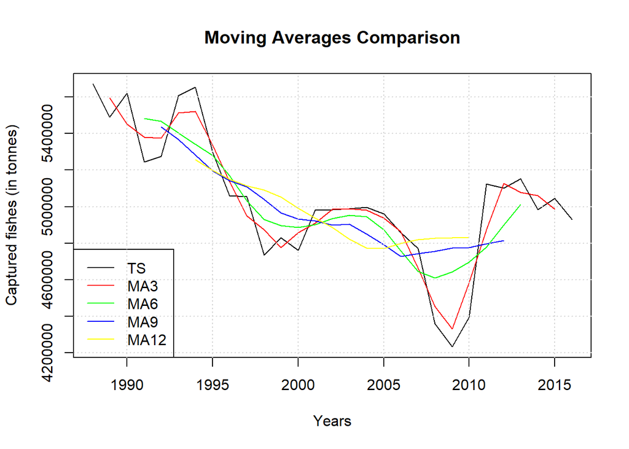

```r
plot(FP_US_TS_recent, xlab = "Years", ylab = "Captured fishes (in tonnes)", main="Moving Averages Comparison")
lines(SMA3_forecast,col="Red")
lines(SMA6_forecast,col="Green")
lines(SMA9_forecast,col="Blue")
lines(SMA12_forecast,col="yellow")
legend(x = "bottomleft",legend = c("TS","MA3","MA6","MA9","MA12"), lty = c(1,1,1,1,1), col=c("black","red","green","blue","yellow"))
grid(nx=NULL, ny=NULL)
```

```r
SMA_forecast <- forecast(SMA3_forecast,h=6)
SMA_forecast
```

```
##      Point Forecast   Lo 80   Hi 80   Lo 95   Hi 95
## 2016        4986988 4804071 5169905 4707240 5266735
## 2017        4986988 4728317 5245659 4591385 5382591
## 2018        4986988 4670187 5303788 4502483 5471492
## 2019        4986988 4621181 5352794 4427535 5546441
## 2020        4986988 4578006 5395970 4361504 5612472
## 2021        4986988 4538972 5435004 4301806 5672169
```

#Our data is dependent on the recent values, thus we have decided to go ahead with SMA with order 3. Since the order is smaller, the weight is larger on the recent period.

```r
attributes(SMA_forecast)
```

```
## $names
##  [1] "model"     "mean"      "level"     "x"         "upper"     "lower"
##  [7] "fitted"    "method"    "series"    "residuals"
##
## $class
## [1] "forecast"
```

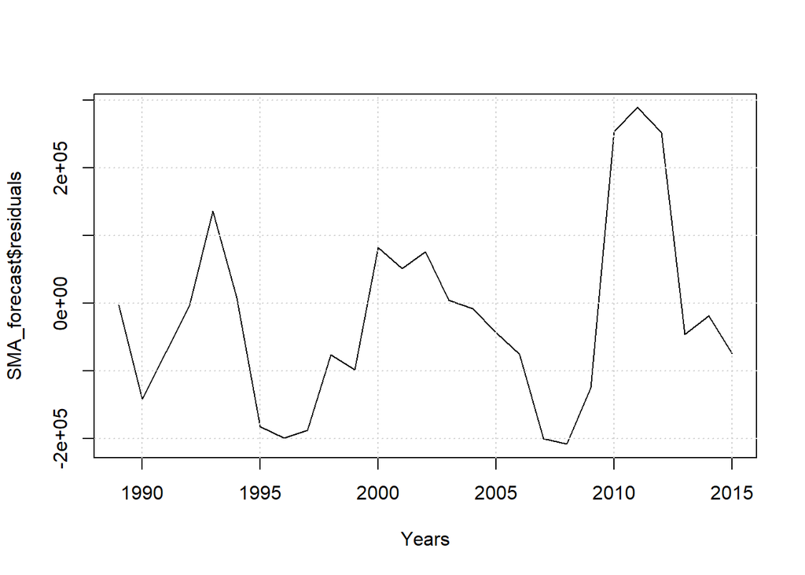

```r
plot(SMA_forecast$residuals, xlab = "Years")
grid(nx=NULL, ny=NULL)
```

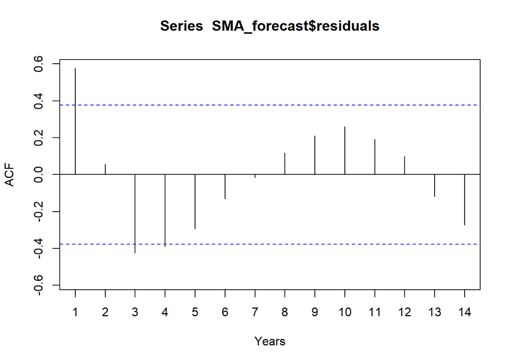

```r
Acf(SMA_forecast$residuals, xlab = "Years")
```

#Acf shows fairly high correlation between the residuals. This is not ideal.

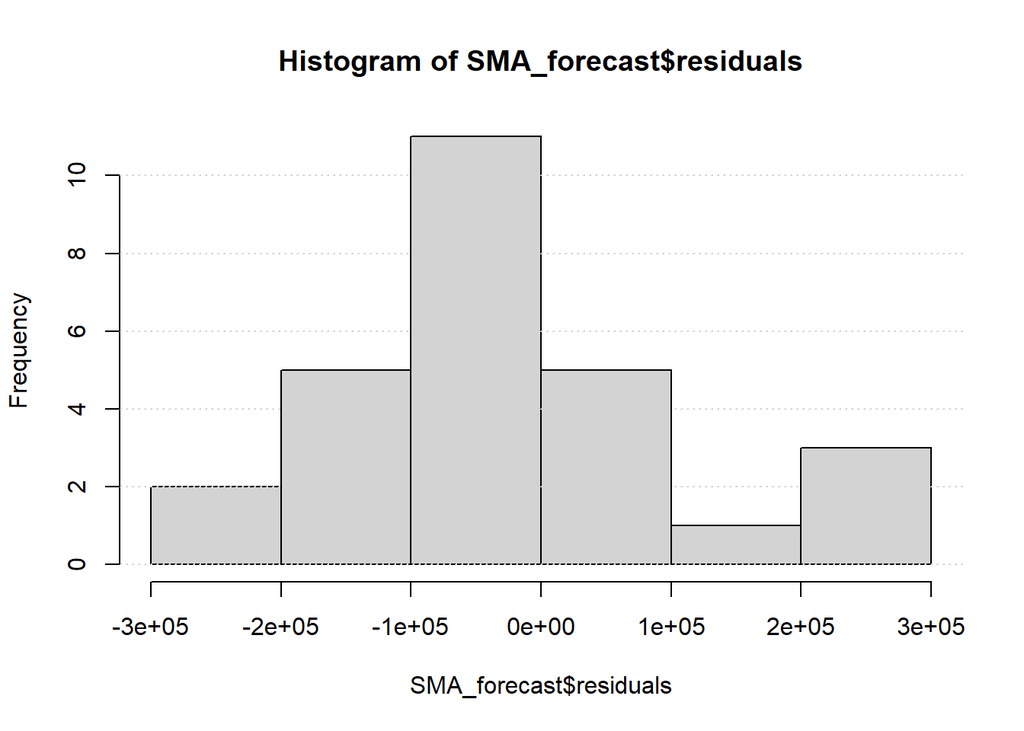

```r
hist(SMA_forecast$residuals)
grid(nx=NA, ny=NULL)
```

#The residuals seem a bit right skewed. The histogram also tells us that most of the residuals are on the left side of the mean.

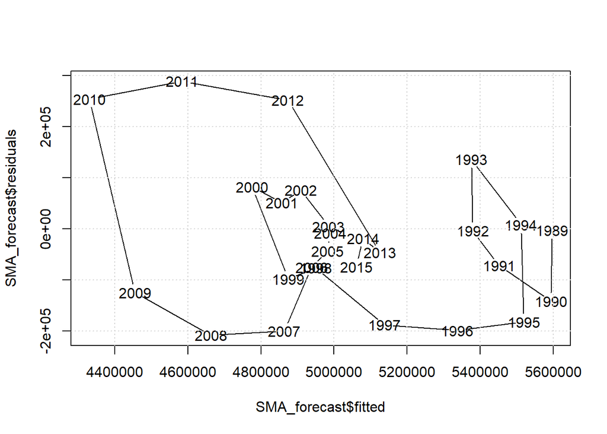

```r
plot(SMA_forecast$fitted,SMA_forecast$residuals)
grid(nx=NULL, ny=NULL)
```

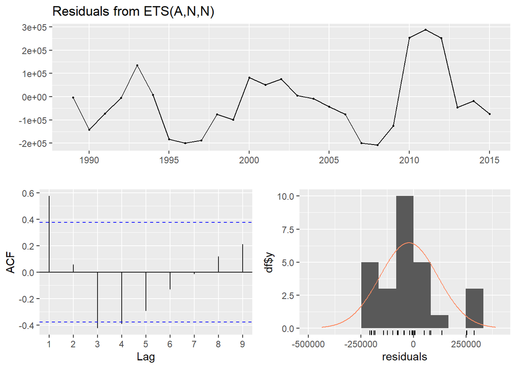

```
##
##  Ljung-Box test
##
## data:  Residuals from ETS(A,N,N)
## Q* = 24.213, df = 3, p-value = 2.255e-05
##
## Model df: 2.   Total lags used: 5
```

```r
checkresiduals(SMA_forecast)
```

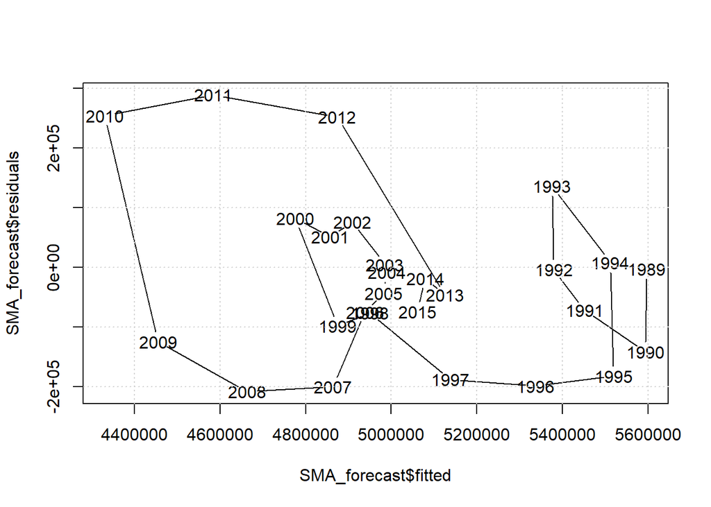

```r
plot(SMA_forecast$fitted,SMA_forecast$residuals)
grid(nx=NULL, ny=NULL)
```

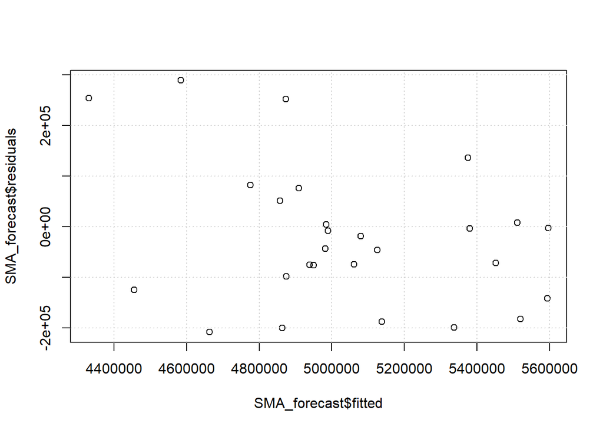

```r
plot.ts(SMA_forecast$fitted,SMA_forecast$residuals,xy.labels = FALSE,xy.lines = FALSE)
grid(nx=NULL, ny=NULL)
```

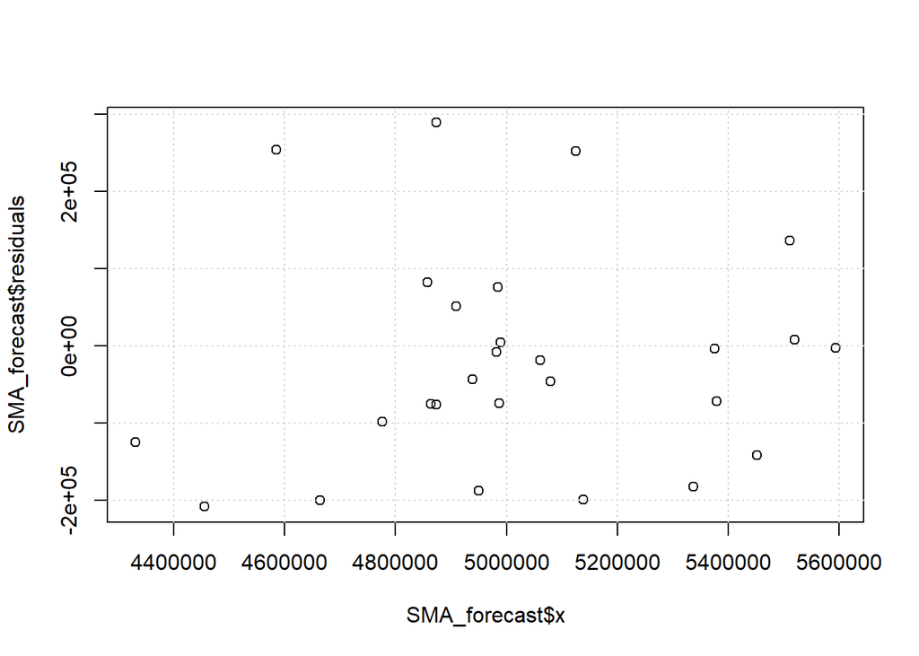

```r
plot.ts(SMA_forecast$x,SMA_forecast$residuals,xy.labels = FALSE,xy.lines = FALSE)
grid(nx=NULL, ny=NULL)
```

#Here we don’t see a pattern in the graph. This is a good sign. The residuals are scattered randomly.

```r
accuracy(SMA_forecast)
```

```
##                     ME     RMSE      MAE       MPE     MAPE      MASE      ACF1
## Training set -22583.83 137342.9 108031.7 -0.467046 2.197547 0.9638667 0.5752261
```

#SMA end

#HW start

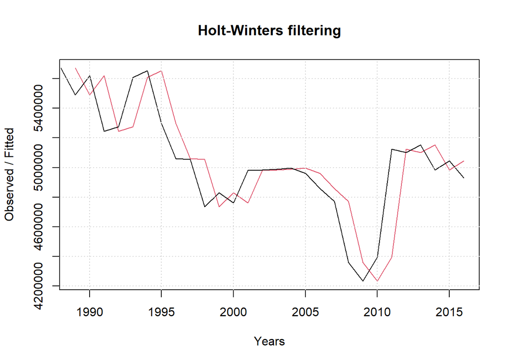

```r
HoltWinters_TS_recent = HoltWinters(FP_US_TS_recent,beta=FALSE,gamma=FALSE)
plot(HoltWinters_TS_recent, xlab="Years")
grid(nx=NULL, ny=NULL)
```

```r
attributes(HoltWinters_TS_recent)
```

```
## $names
## [1] "fitted"       "x"            "alpha"        "beta"         "gamma"
## [6] "coefficients" "seasonal"     "SSE"          "call"
##
## $class
## [1] "HoltWinters"
```

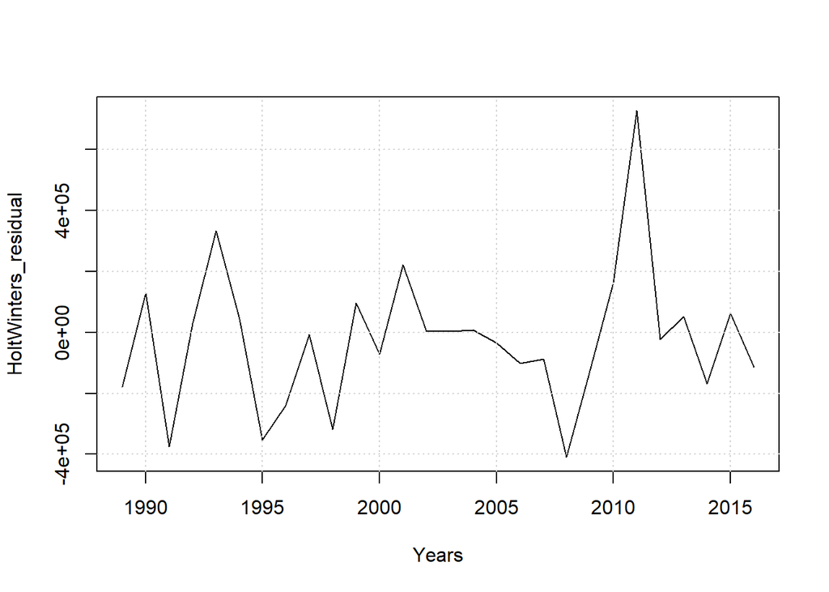

```r
HoltWinters_residual <- residuals(HoltWinters(FP_US_TS_recent,beta = FALSE, gamma = FALSE))
plot(HoltWinters_residual, xlab = "Years")
grid(nx=NULL, ny=NULL)
```

#We don’t see any pattern between the residuals.

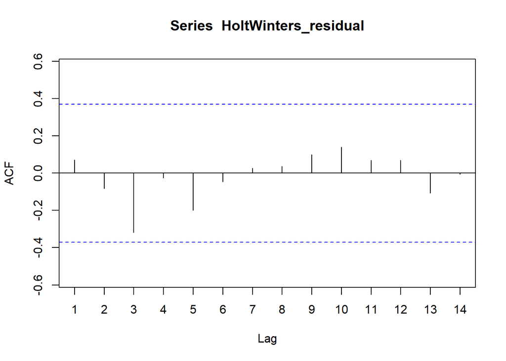

```r
Acf(HoltWinters_residual)
```

#The acf states that there is no significant correlation.

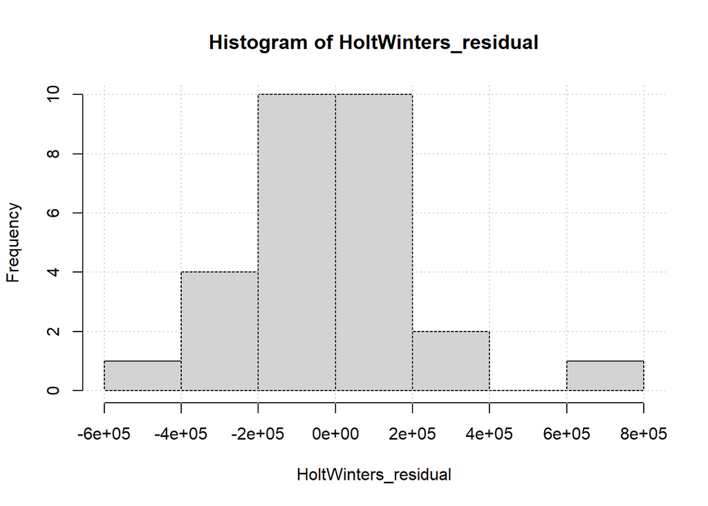

```r
hist(HoltWinters_residual)
grid(nx=NULL, ny=NULL)
```

#The errors are also distributed around the mean that is 0. This seems good.

```r
plot(HoltWinters_TS_recent$fitted,HoltWinters_residual, xlab = "Years")
grid(nx=NULL, ny=NULL)
```

[output not shown]

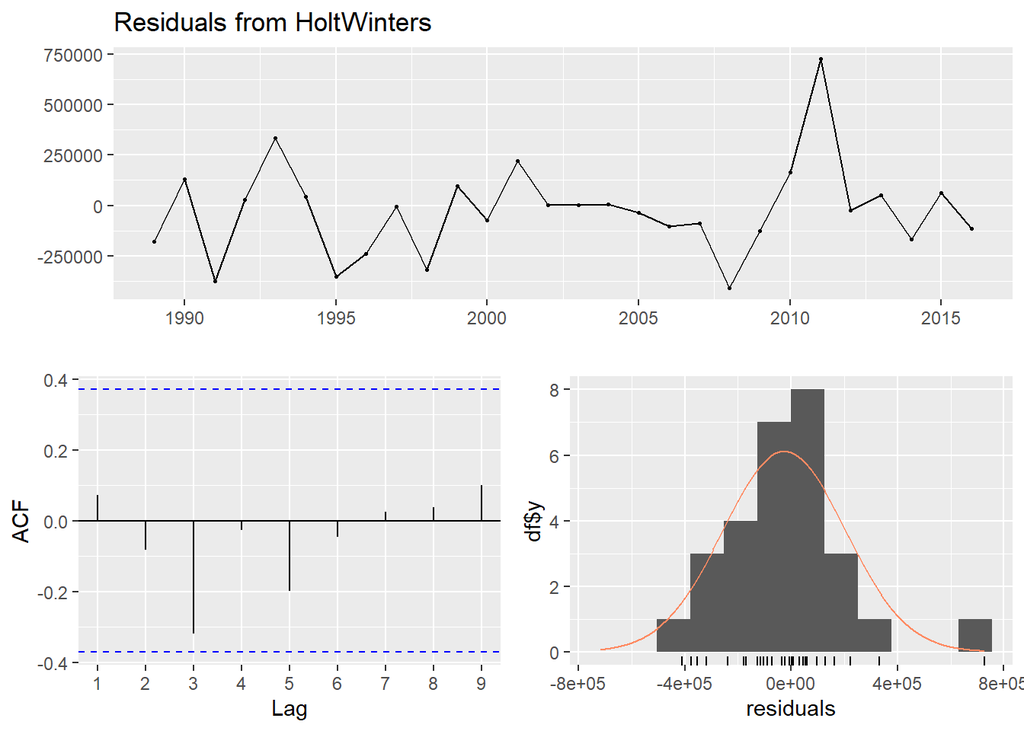

```r
checkresiduals(HoltWinters_TS_recent)
```

```r
plot(HoltWinters_TS_recent$fitted,HoltWinters_TS_recent$residuals, xlab = "Years")
grid(nx=NULL, ny=NULL)
```

[output not shown]

```r
plot.ts(HoltWinters_TS_recent$fitted,HoltWinters_TS_recent$residuals,xy.labels = FALSE,xy.lines = FALSE, xlab = "Years")
grid(nx=NULL, ny=NULL)
```

[output not shown]

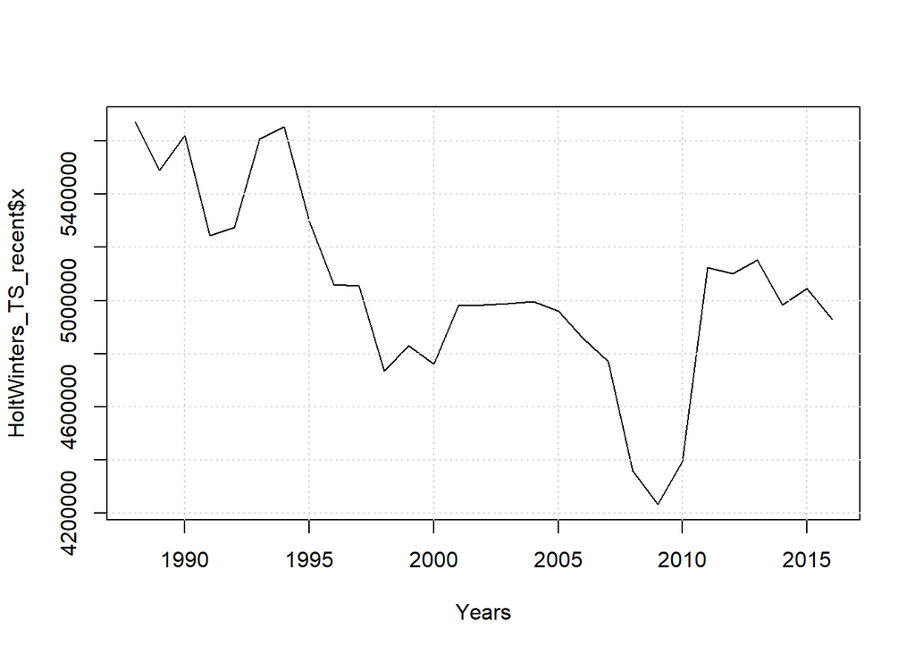

```r
plot.ts(HoltWinters_TS_recent$x,HoltWinters_TS_recent$residuals,xy.labels = FALSE,xy.lines = FALSE, xlab = "Years")
grid(nx=NULL, ny=NULL)
```

```r
HoltWinters_forecast = forecast(HoltWinters_TS_recent,h=3)
HoltWinters_forecast
```

```
##      Point Forecast   Lo 80   Hi 80   Lo 95   Hi 95
## 2017        4931025 4635287 5226762 4478733 5383316
## 2018        4931025 4512802 5349247 4291409 5570640
## 2019        4931025 4418815 5443234 4147667 5714382
```

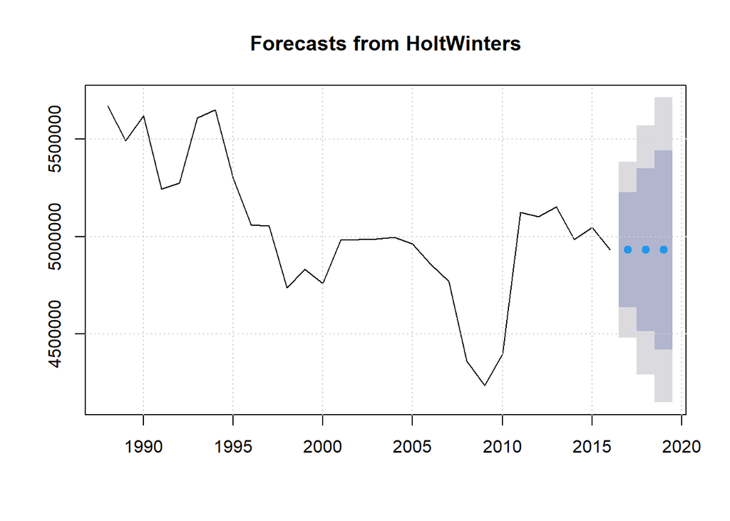

```r
plot(HoltWinters_forecast)
grid(nx = NULL, ny = NULL)
```

#As per HoltsWinter, the total number of fishses to be captured is 4931025 metric tons.

```r
accuracy(HoltWinters_forecast)
```

```
##                     ME     RMSE      MAE        MPE     MAPE      MASE
## Training set -26417.51 228141.6 160036.7 -0.6050042 3.205737 0.9999942
##                    ACF1
## Training set 0.07209646
```

#HW end

#Decomp start

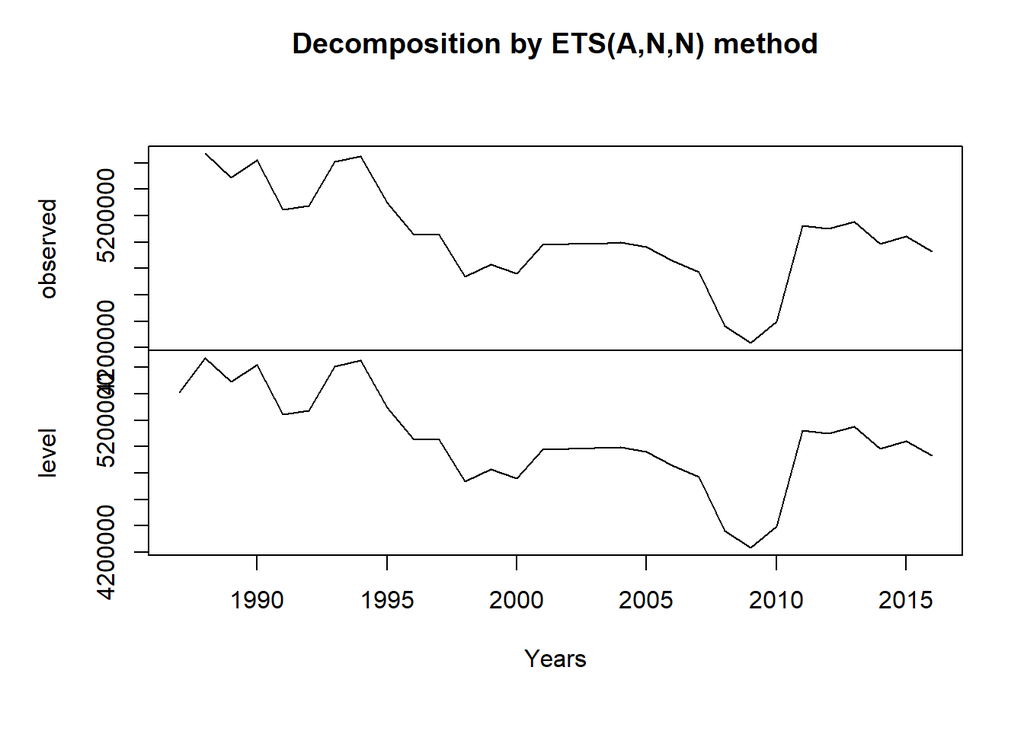

```r
ets_forecast = ets(FP_US_TS_recent)
#plot(ets_forecast, xlab = "Years", yaxt='n')
plot(ets_forecast, xlab = "Years")
```

#Again the observed and level is the same as there is no seasonlaity to influence the data.

```r
attributes(ets_forecast)
```

```
## $names
##  [1] "loglik"     "aic"        "bic"        "aicc"       "mse"
##  [6] "amse"       "fit"        "residuals"  "fitted"     "states"
## [11] "par"        "m"          "method"     "series"     "components"
## [16] "call"       "initstate"  "sigma2"     "x"
##
## $class
## [1] "ets"
```

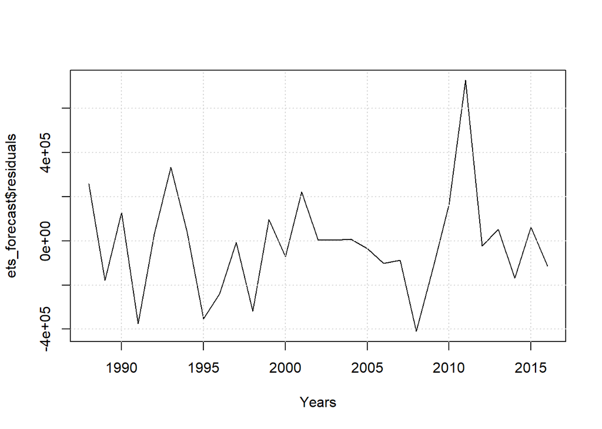

```r
plot(ets_forecast$residuals, xlab = "Years")
grid(nx=NULL, ny=NULL)
```

#The plot is equally spread residuals around the horizontal line without a distinct pattern. This is a good indication it is not a non-linear relationship.

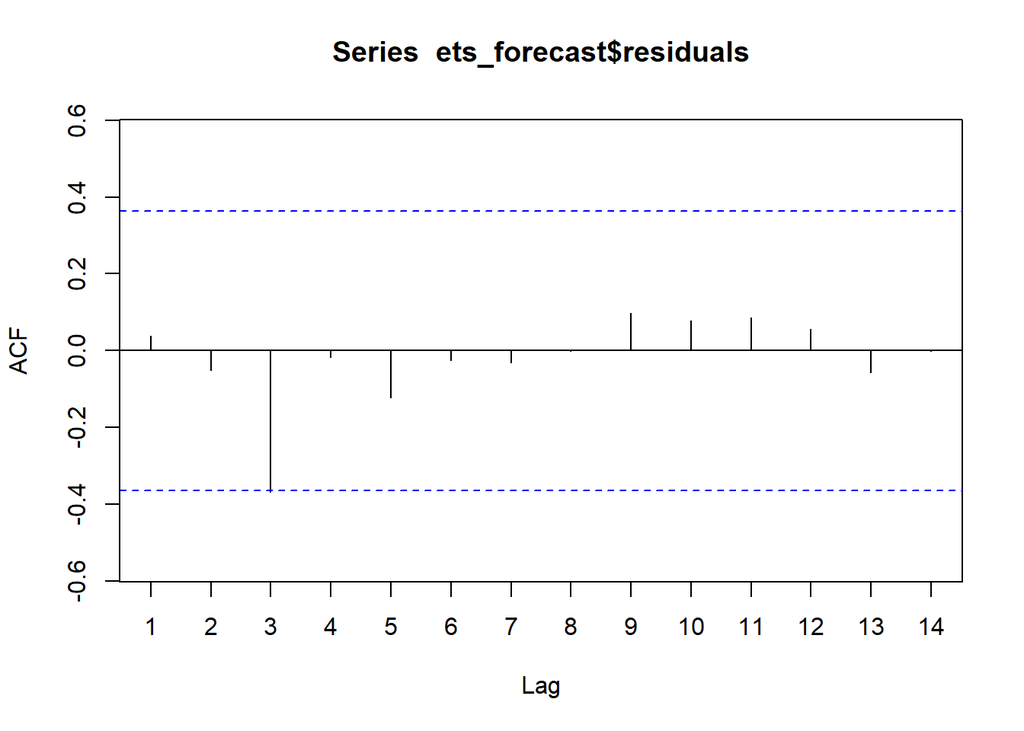

```r
Acf(ets_forecast$residuals)
```

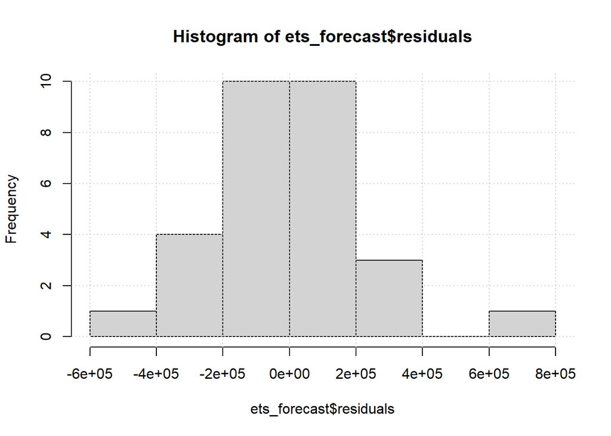

```r
hist(ets_forecast$residuals)
grid(nx=NULL, ny=NULL)
```

#The histogram is seems normal with an outlier. This seems good for the model.

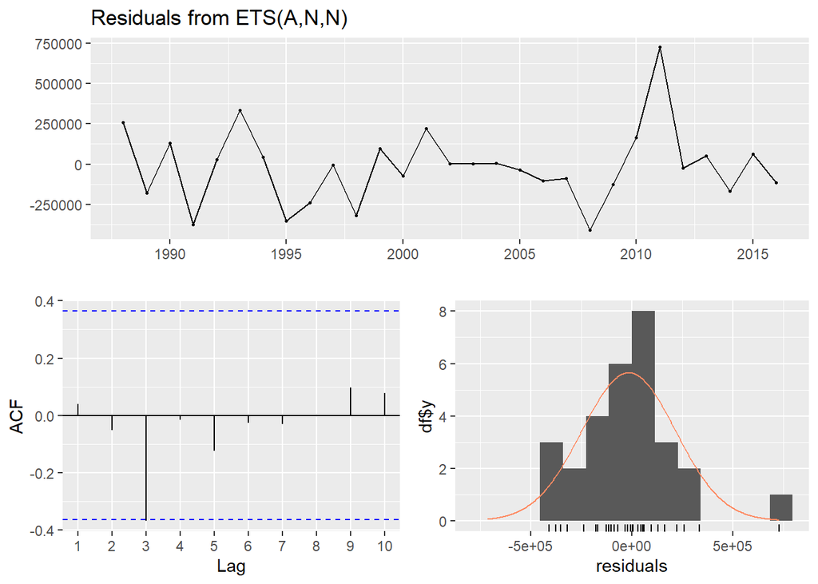

```
##
##  Ljung-Box test
##
## data:  Residuals from ETS(A,N,N)
## Q* = 5.44, df = 4, p-value = 0.2451
##
## Model df: 2.   Total lags used: 6
```

```r
checkresiduals(ets_forecast)
```

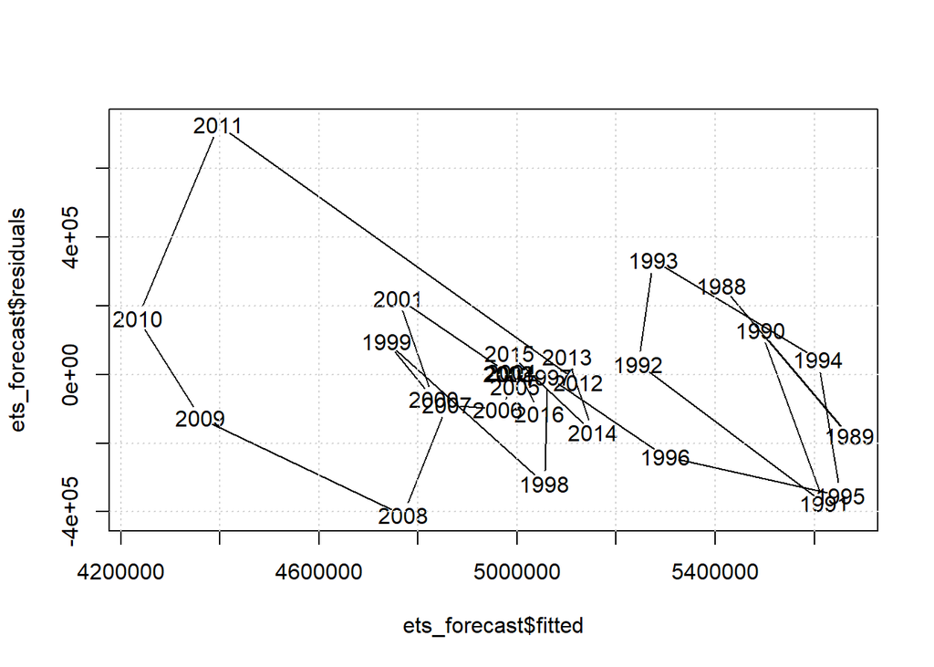

```r
plot(ets_forecast$fitted,ets_forecast$residuals)
grid(nx=NULL, ny=NULL)
```

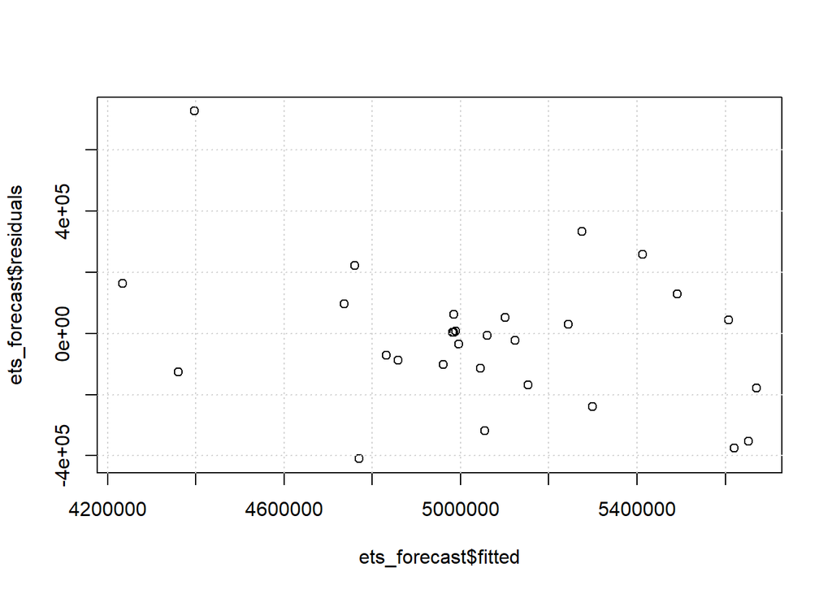

```r
plot.ts(ets_forecast$fitted,ets_forecast$residuals,xy.labels = FALSE,xy.lines = FALSE)
grid(nx=NULL, ny=NULL)
```

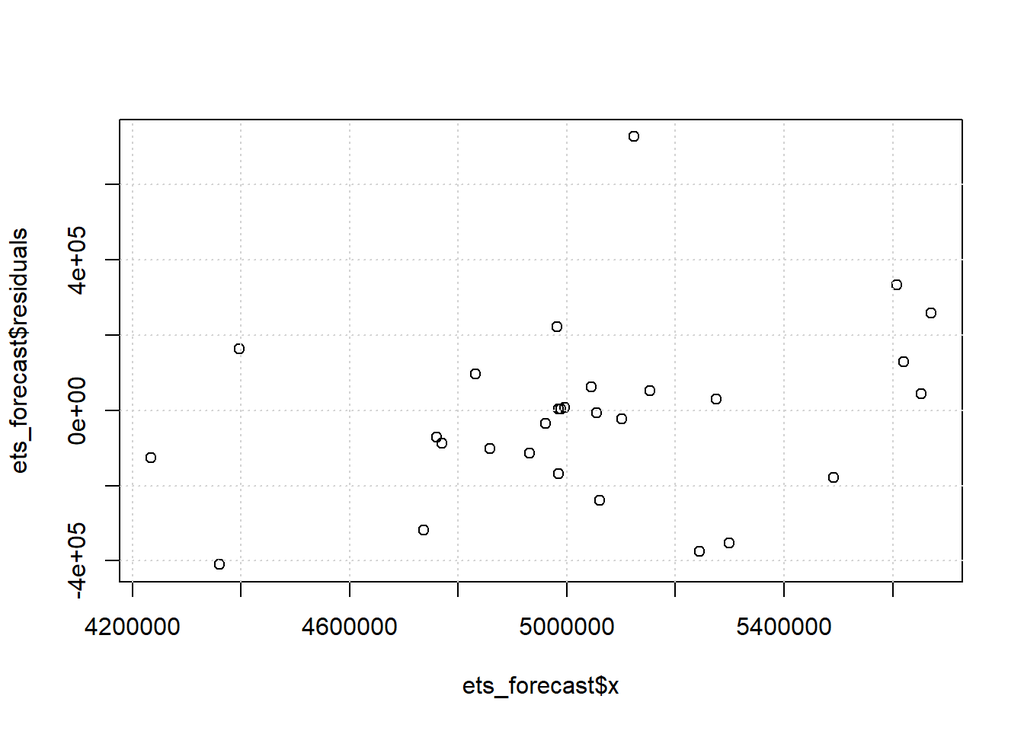

```r
plot.ts(ets_forecast$x,ets_forecast$residuals,xy.labels = FALSE,xy.lines = FALSE)
grid(nx=NULL, ny=NULL)
```

#Here we don’t see any specific pattern here for the residuals.

```r
accuracy(ets_forecast)
```

```
##                     ME     RMSE      MAE        MPE     MAPE    MASE       ACF1
## Training set -16612.05 229233.4 163411.2 -0.4272953 3.252019 1.02108 0.03910814
```

```r
forecast(ets_forecast,h=3)
```

```
##      Point Forecast   Lo 80   Hi 80   Lo 95   Hi 95
## 2017        4931029 4626568 5235489 4465396 5396661
## 2018        4931029 4500478 5361579 4272558 5589499
## 2019        4931029 4403723 5458334 4124584 5737473
```

#The decomposition model forecasts that 4931029 metric tons of fishes need to be captured to suffice the needs of United states.

#Decomp end

#ARIMA start

```r
ndiffs(FP_US_TS_recent)
```

```
## [1] 1
```

#This gives the d value in the Arima function. It tells you the number of differences that you should take to make the time series stationary.

```r
Arima_FP_TS = auto.arima(FP_US_TS_recent, trace = TRUE, stepwise = FALSE)
```

```
##
##  ARIMA(0,1,0)                    : 772.5265
##  ARIMA(0,1,0) with drift         : 774.4747
##  ARIMA(0,1,1)                    : 774.6563
##  ARIMA(0,1,1) with drift         : 776.8304
##  ARIMA(0,1,2)                    : 777.1605
##  ARIMA(0,1,2) with drift         : 779.5101
##  ARIMA(0,1,3)                    : 775.9411
##  ARIMA(0,1,3) with drift         : Inf
##  ARIMA(0,1,4)                    : 778.0335
##  ARIMA(0,1,4) with drift         : 780.1718
##  ARIMA(0,1,5)                    : Inf
##  ARIMA(0,1,5) with drift         : Inf
##  ARIMA(1,1,0)                    : 774.6754
##  ARIMA(1,1,0) with drift         : 776.8509
##  ARIMA(1,1,1)                    : 777.124
##  ARIMA(1,1,1) with drift         : 779.4869
##  ARIMA(1,1,2)                    : 778.4902
##  ARIMA(1,1,2) with drift         : Inf
##  ARIMA(1,1,3)                    : 777.0049
##  ARIMA(1,1,3) with drift         : Inf
##  ARIMA(1,1,4)                    : 780.2771
##  ARIMA(1,1,4) with drift         : 782.6818
##  ARIMA(2,1,0)                    : 777.0275
##  ARIMA(2,1,0) with drift         : 779.3654
##  ARIMA(2,1,1)                    : 779.1732
##  ARIMA(2,1,1) with drift         : 781.8711
##  ARIMA(2,1,2)                    : Inf
##  ARIMA(2,1,2) with drift         : Inf
##  ARIMA(2,1,3)                    : 780.2759
##  ARIMA(2,1,3) with drift         : Inf
##  ARIMA(3,1,0)                    : 777.0024
##  ARIMA(3,1,0) with drift         : 779.4954
##  ARIMA(3,1,1)                    : 779.5692
##  ARIMA(3,1,1) with drift         : 782.3931
##  ARIMA(3,1,2)                    : 782.1542
##  ARIMA(3,1,2) with drift         : Inf
##  ARIMA(4,1,0)                    : 779.9306
##  ARIMA(4,1,0) with drift         : 782.7314
##  ARIMA(4,1,1)                    : 782.8111
##  ARIMA(4,1,1) with drift         : Inf
##  ARIMA(5,1,0)                    : 781.1797
##  ARIMA(5,1,0) with drift         : 783.9138
##
##
##
##  Best model: ARIMA(0,1,0)
```

```r
Arima_FP_TS
```

```
## Series: FP_US_TS_recent
## ARIMA(0,1,0)
##
## sigma^2 estimated as 5.205e+10:  log likelihood=-385.19
## AIC=772.37   AICc=772.53   BIC=773.7
```

#It shows that the best model using Arima is (0,1,0) since it has the lowest AIC.

```r
Arima_FP_TS = auto.arima(FP_US_TS_recent, trace = TRUE, stepwise = FALSE, ic = c("bic"))
```

```
##
##  ARIMA(0,1,0)                    : 773.7049
##  ARIMA(0,1,0) with drift         : 776.6592
##  ARIMA(0,1,1)                    : 776.8408
##  ARIMA(0,1,1) with drift         : 779.8271
##  ARIMA(0,1,2)                    : 780.1571
##  ARIMA(0,1,2) with drift         : 783.0998
##  ARIMA(0,1,3)                    : 779.5308
##  ARIMA(0,1,3) with drift         : Inf
##  ARIMA(0,1,4)                    : 781.9672
##  ARIMA(0,1,4) with drift         : 784.165
##  ARIMA(0,1,5)                    : Inf
##  ARIMA(0,1,5) with drift         : Inf
##  ARIMA(1,1,0)                    : 776.8598
##  ARIMA(1,1,0) with drift         : 779.8475
##  ARIMA(1,1,1)                    : 780.1206
##  ARIMA(1,1,1) with drift         : 783.0766
##  ARIMA(1,1,2)                    : 782.0799
##  ARIMA(1,1,2) with drift         : Inf
##  ARIMA(1,1,3)                    : 780.9387
##  ARIMA(1,1,3) with drift         : Inf
##  ARIMA(1,1,4)                    : 784.2704
##  ARIMA(1,1,4) with drift         : 786.4072
##  ARIMA(2,1,0)                    : 780.0241
##  ARIMA(2,1,0) with drift         : 782.9551
##  ARIMA(2,1,1)                    : 782.7629
##  ARIMA(2,1,1) with drift         : 785.8048
##  ARIMA(2,1,2)                    : Inf
##  ARIMA(2,1,2) with drift         : Inf
##  ARIMA(2,1,3)                    : 784.2691
##  ARIMA(2,1,3) with drift         : Inf
##  ARIMA(3,1,0)                    : 780.5921
##  ARIMA(3,1,0) with drift         : 783.4291
##  ARIMA(3,1,1)                    : 783.503
##  ARIMA(3,1,1) with drift         : 786.3864
##  ARIMA(3,1,2)                    : 786.1474
##  ARIMA(3,1,2) with drift         : Inf
##  ARIMA(4,1,0)                    : 783.8644
##  ARIMA(4,1,0) with drift         : 786.7247
##  ARIMA(4,1,1)                    : 786.8043
##  ARIMA(4,1,1) with drift         : Inf
##  ARIMA(5,1,0)                    : 785.1729
##  ARIMA(5,1,0) with drift         : 787.6392
##
##
##
##  Best model: ARIMA(0,1,0)
```

```r
Arima_FP_TS
```

```
## Series: FP_US_TS_recent
## ARIMA(0,1,0)
##
## sigma^2 estimated as 5.205e+10:  log likelihood=-385.19
## AIC=772.37   AICc=772.53   BIC=773.7
```

#This is the same Arima method, that best model using Arima is (0,1,0) considering BIC values.

```r
attributes(Arima_FP_TS)
```

```
## $names
##  [1] "coef"      "sigma2"    "var.coef"  "mask"      "loglik"    "aic"
##  [7] "arma"      "residuals" "call"      "series"    "code"      "n.cond"
## [13] "nobs"      "model"     "bic"       "aicc"      "x"         "fitted"
##
## $class
## [1] "forecast_ARIMA" "ARIMA"          "Arima"
```

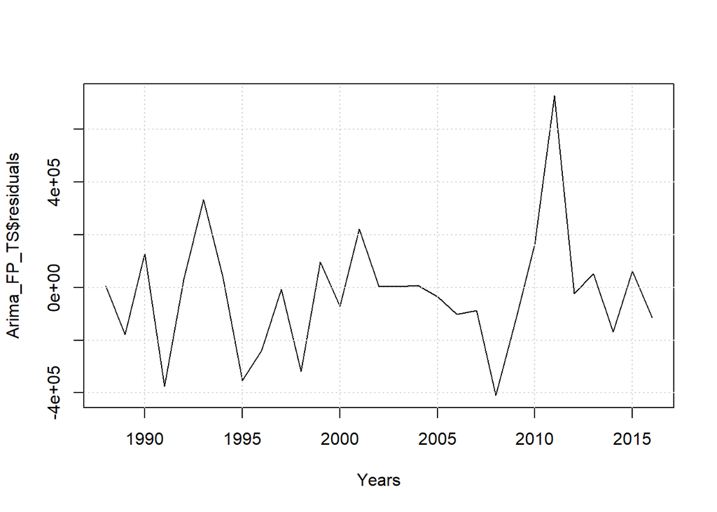

```r
plot(Arima_FP_TS$residuals, xlab = "Years")
grid(nx=NULL, ny=NULL)
```

#The plot is equally spread residuals around the horizontal line without a distinct pattern. This is a good indication it is not a non-linear relationship.

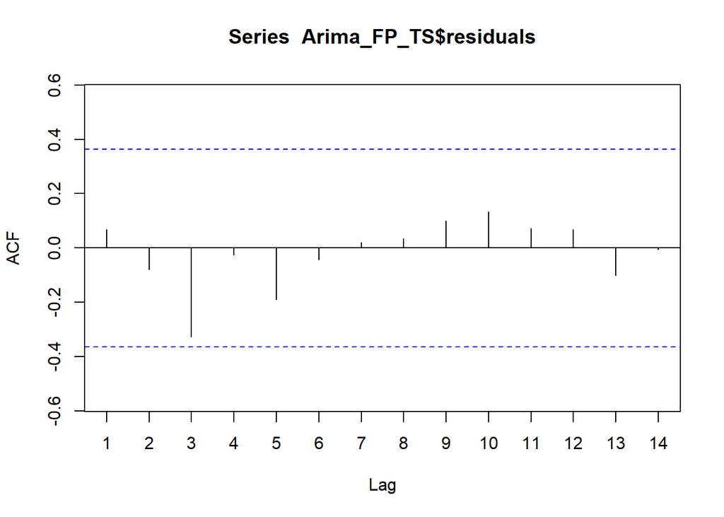

```r
Acf(Arima_FP_TS$residuals)
```

#Here, in the Acf, we don’t see any significant lines which states that there is no correlation between the errors.

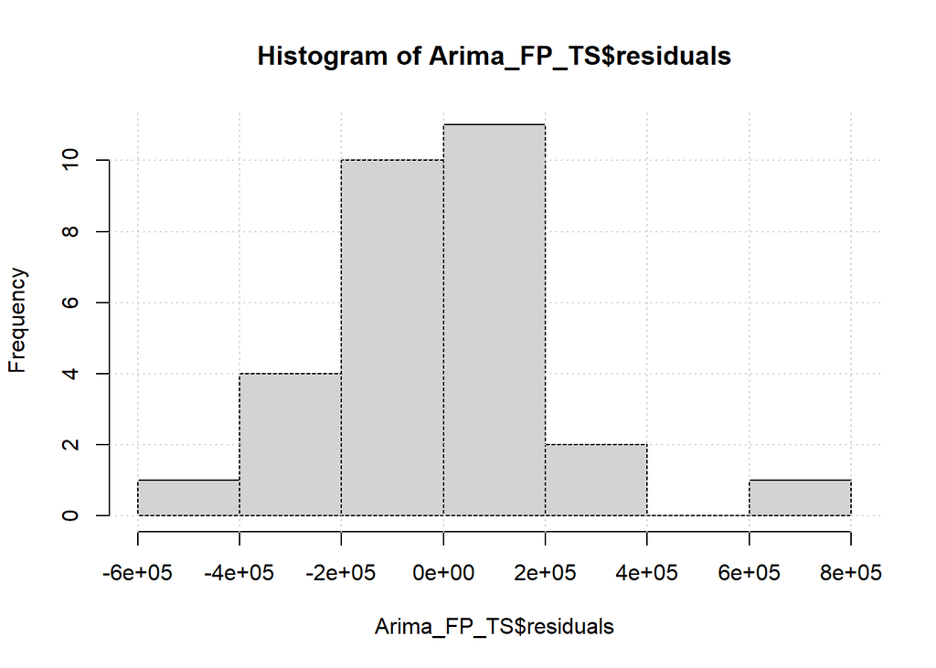

```r
hist(Arima_FP_TS$residuals)
grid(nx=NULL, ny=NULL)
```

#The histogram is right skewed.

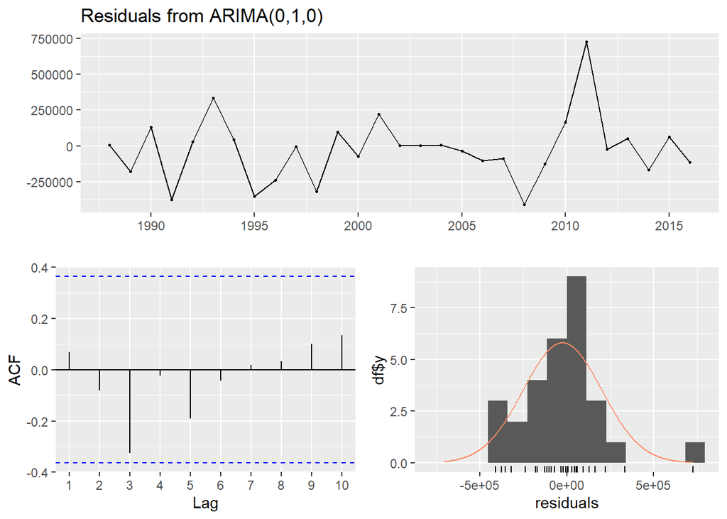

```
##
##  Ljung-Box test
##
## data:  Residuals from ARIMA(0,1,0)
## Q* = 5.4944, df = 6, p-value = 0.4821
##
## Model df: 0.   Total lags used: 6
```

```r
checkresiduals(Arima_FP_TS)
```

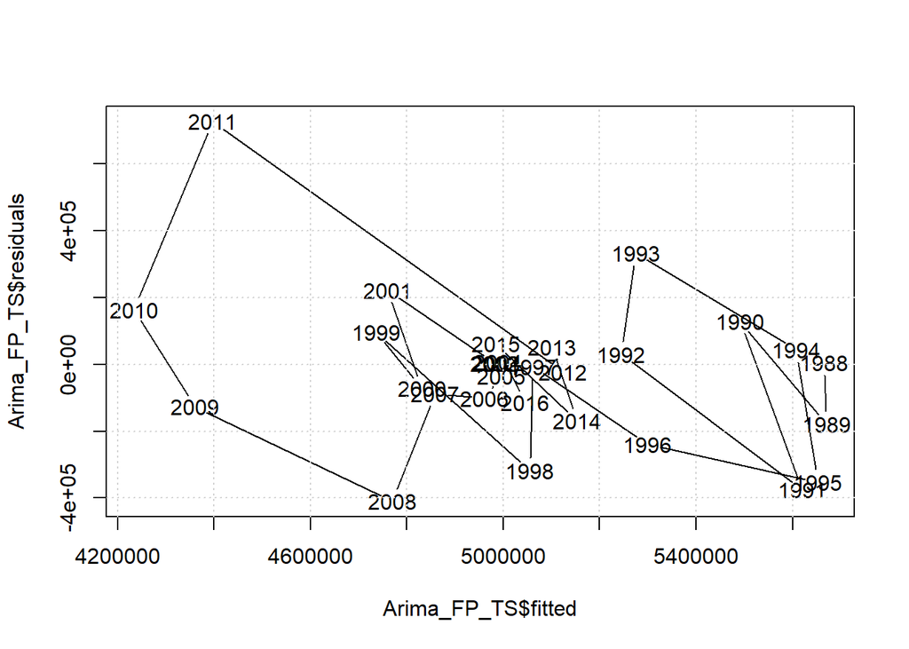

```r
plot(Arima_FP_TS$fitted,Arima_FP_TS$residuals)
grid(nx=NULL, ny=NULL)
```

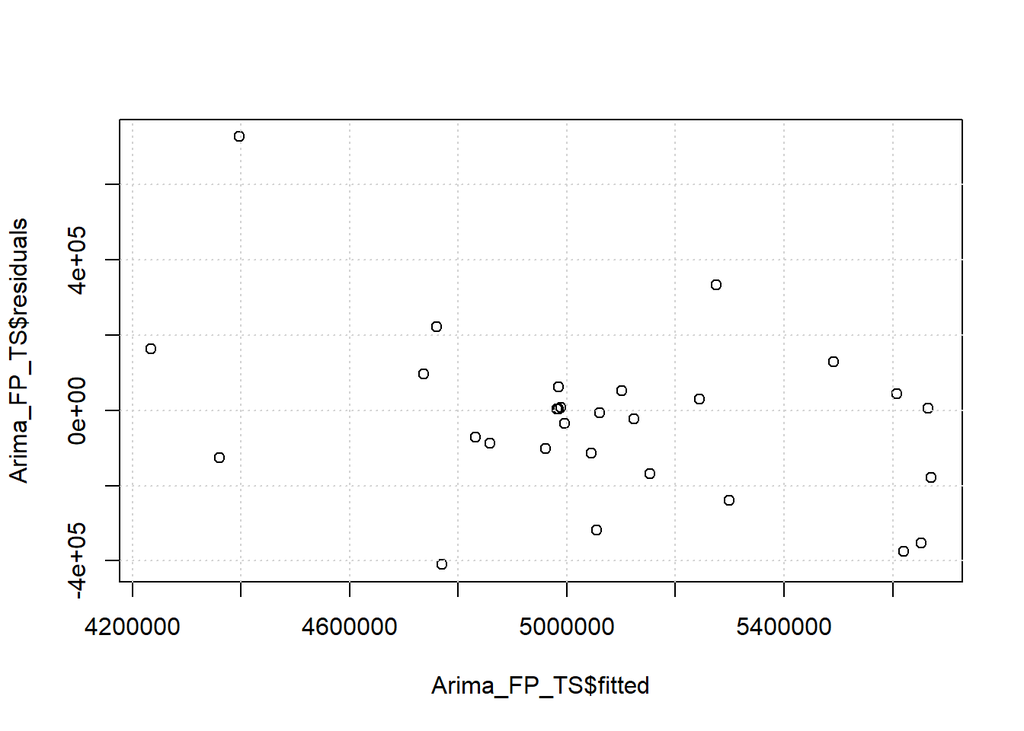

```r
plot.ts(Arima_FP_TS$fitted,Arima_FP_TS$residuals,xy.labels = FALSE,xy.lines = FALSE)
grid(nx=NULL, ny=NULL)
```

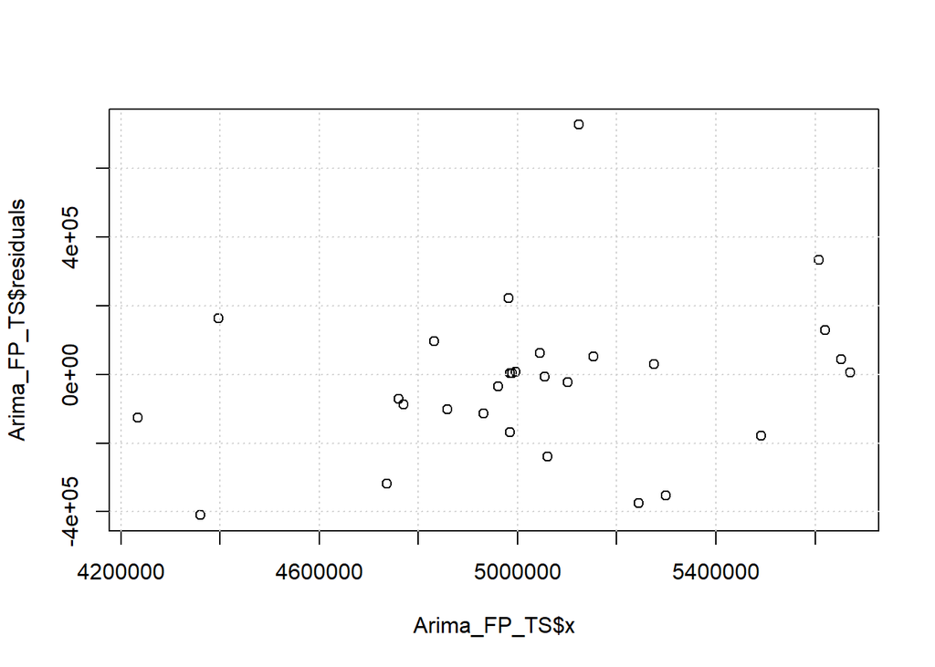

```r
plot.ts(Arima_FP_TS$x,Arima_FP_TS$residuals,xy.labels = FALSE,xy.lines = FALSE)
grid(nx=NULL, ny=NULL)
```

#Here we don’t see any specific pattern here for the residuals.

```r
Arima_Forecast = forecast(Arima_FP_TS, h = 3)
Arima_Forecast
```

```
##      Point Forecast   Lo 80   Hi 80   Lo 95   Hi 95
## 2017        4931017 4638640 5223394 4483865 5378169
## 2018        4931017 4517534 5344500 4298649 5563385
## 2019        4931017 4424605 5437429 4156527 5705507
```

#The arima model forecasts that 4931017 metric tons of fishes need to be captured to suffice the needs of United states.

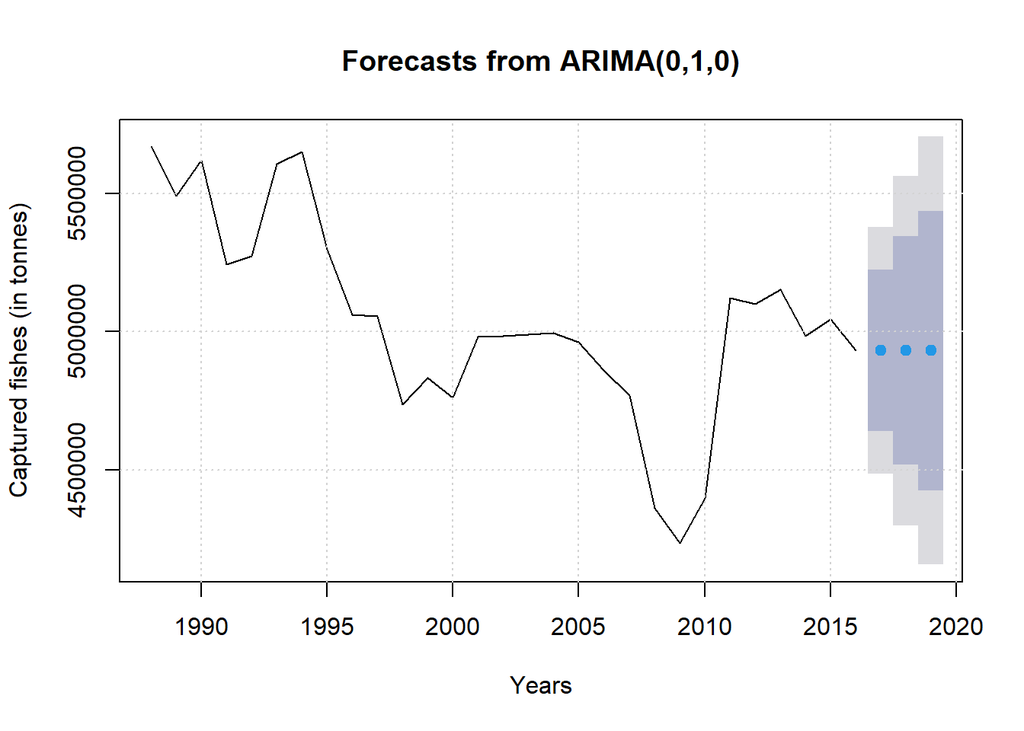

```r
plot(Arima_Forecast, xlab = "Years", ylab = "Captured fishes (in tonnes)")
grid(nx=NULL, ny=NULL)
```

```r
accuracy(Arima_Forecast)
```

```
##                    ME     RMSE      MAE        MPE     MAPE      MASE
## Training set -25309.6 224174.9 154714.6 -0.5806591 3.098657 0.9667391
##                    ACF1
## Training set 0.06850866
```

#ARIMA end

#Working on the model

#RWF start

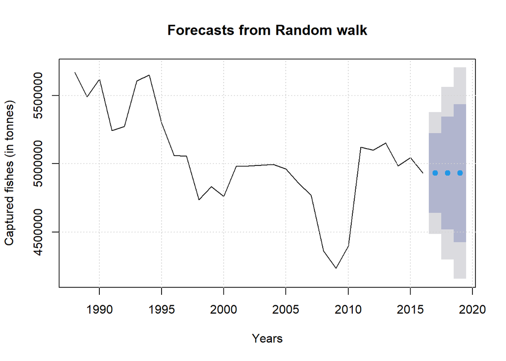

```r
rwf_forecast = rwf(FP_US_TS_recent,3)
plot (rwf_forecast,  xlab = "Years", ylab = "Captured fishes (in tonnes)")
grid(nx=NULL, ny=NULL)
```

```r
attributes(rwf_forecast)
```

```
## $names
##  [1] "method"    "model"     "lambda"    "x"         "fitted"    "residuals"
##  [7] "series"    "mean"      "level"     "lower"     "upper"
##
## $class
## [1] "forecast"
```

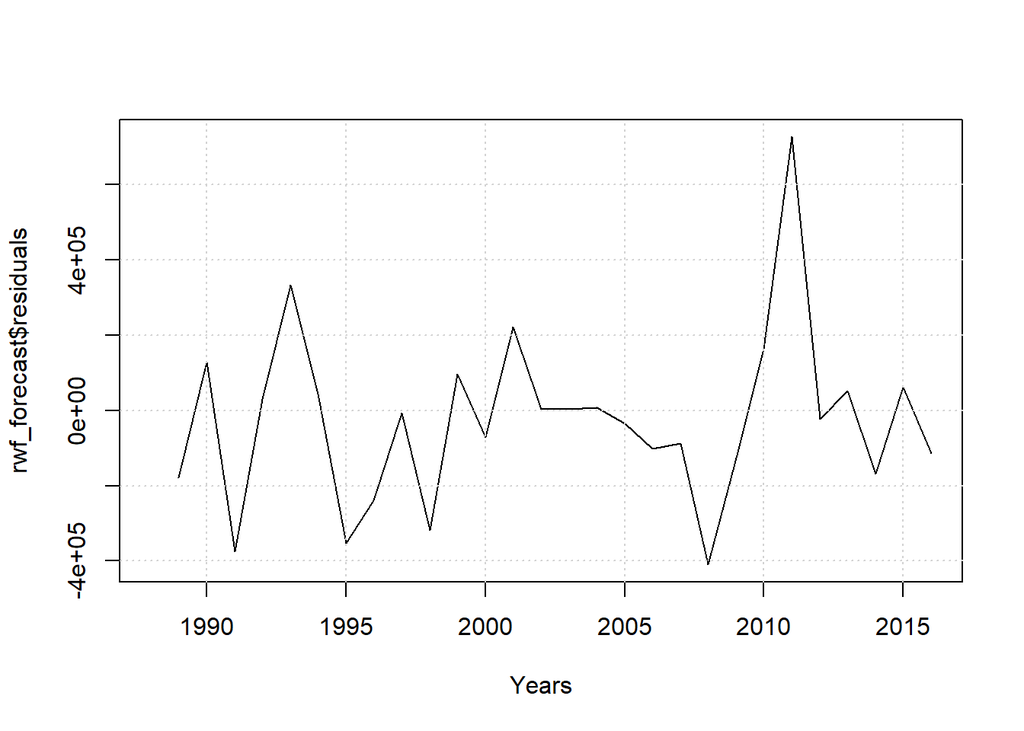

```r
plot(rwf_forecast$residuals, xlab ="Years")
grid(nx=NULL, ny=NULL)
```

#Residuals don’t show any pattern.

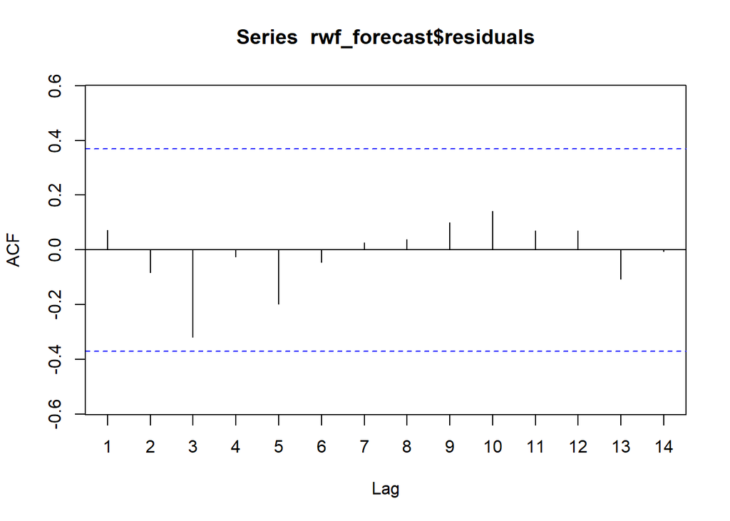

```r
Acf(rwf_forecast$residuals)
```

#Acf shows no sginficant correlation.

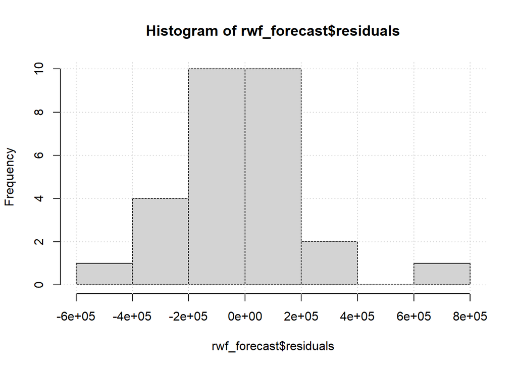

```r
hist(rwf_forecast$residuals)
grid(nx=NULL, ny=NULL)
```

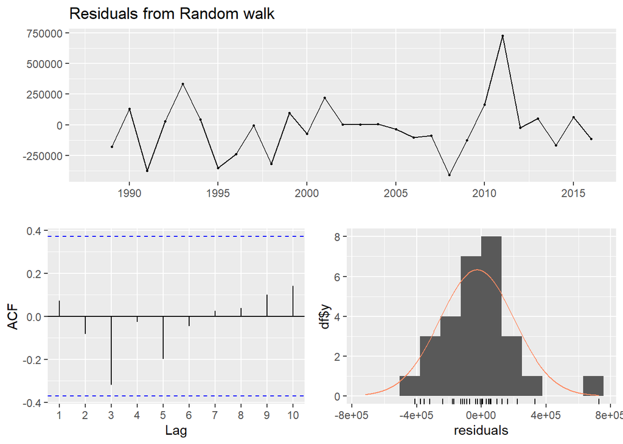

```
##
##  Ljung-Box test
##
## data:  Residuals from Random walk
## Q* = 5.3312, df = 6, p-value = 0.5021
##
## Model df: 0.   Total lags used: 6
```

```r
checkresiduals(rwf_forecast)
```

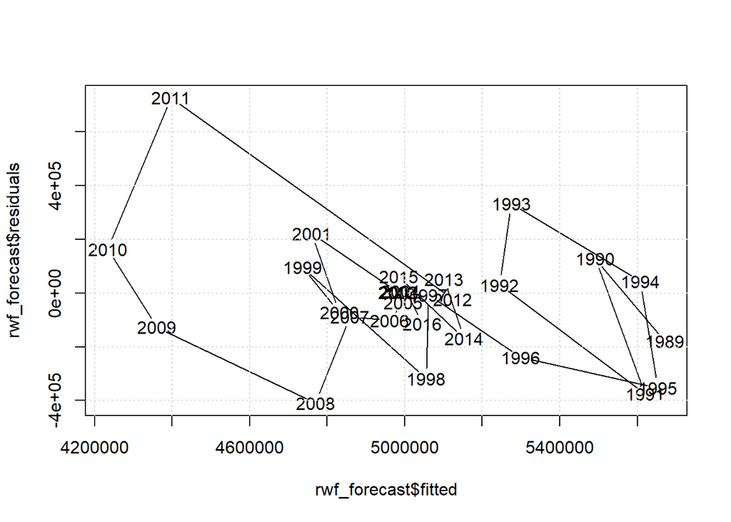

```r
plot(rwf_forecast$fitted,rwf_forecast$residuals)
grid(nx=NULL, ny=NULL)
```

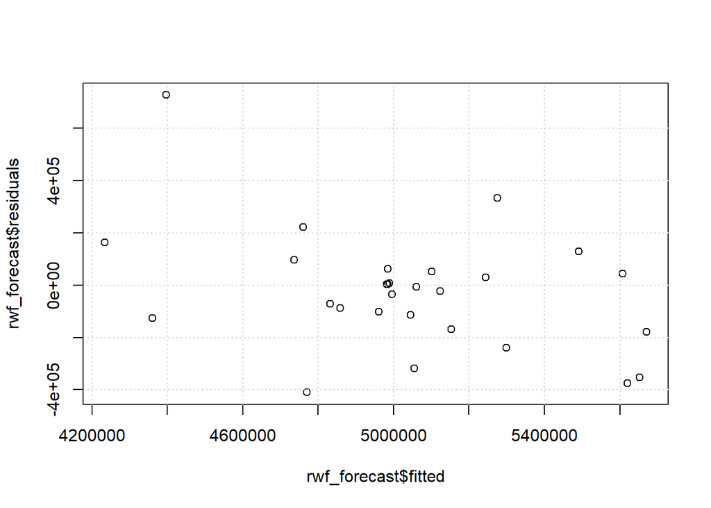

```r
plot.ts(rwf_forecast$fitted,rwf_forecast$residuals,xy.labels = FALSE,xy.lines = FALSE)
grid(nx=NULL, ny=NULL)
```

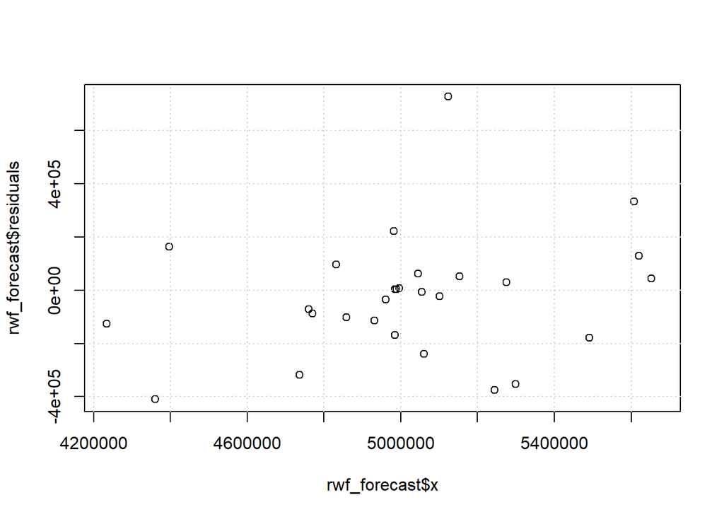

```r
plot.ts(rwf_forecast$x,rwf_forecast$residuals,xy.labels = FALSE,xy.lines = FALSE)
grid(nx=NULL, ny=NULL)
```

```r
accuracy(rwf_forecast)
```

```
##                     ME     RMSE      MAE        MPE     MAPE MASE       ACF1
## Training set -26416.04 228140.4 160037.6 -0.6049683 3.205752    1 0.07203671
```

```r
forecast(rwf_forecast,h=3)
```

```
##      Point Forecast   Lo 80   Hi 80   Lo 95   Hi 95
## 2017        4931017 4638643 5223391 4483870 5378164
## 2018        4931017 4517538 5344496 4298656 5563378
## 2019        4931017 4424611 5437423 4156536 5705498
```

#The rwf model forecasts that 4931017 metric tons of fishes need to be captured to suffice the needs of United states #RWF end

#Regression start

```r
Regression_forecasts = lm(FP_US$`Capture fisheries production (metric tons)`~lag(FP_US$`Capture fisheries production (metric tons)`,+1),data = FP_US)
Regression_forecasts
```

```
##
## Call:
## lm(formula = FP_US$`Capture fisheries production (metric tons)` ~
##     lag(FP_US$`Capture fisheries production (metric tons)`, +1),
##     data = FP_US)
##
## Coefficients:
##                                                 (Intercept)
##                                                  -1.974e-09
## lag(FP_US$`Capture fisheries production (metric tons)`, +1)
##                                                   1.000e+00
```

```r
summary(Regression_forecasts)
```

```
##
## Call:
## lm(formula = FP_US$`Capture fisheries production (metric tons)` ~
##     lag(FP_US$`Capture fisheries production (metric tons)`, +1),
##     data = FP_US)
##
## Residuals:
##        Min         1Q     Median         3Q        Max
## -4.503e-09 -1.580e-11  5.160e-11  1.264e-10  7.671e-10
##
## Coefficients:
##                                                               Estimate
## (Intercept)                                                 -1.974e-09
## lag(FP_US$`Capture fisheries production (metric tons)`, +1)  1.000e+00
##                                                             Std. Error
## (Intercept)                                                  3.268e-10
## lag(FP_US$`Capture fisheries production (metric tons)`, +1)  7.575e-17
##                                                                t value Pr(>|t|)
## (Intercept)                                                 -6.039e+00 1.39e-07
## lag(FP_US$`Capture fisheries production (metric tons)`, +1)  1.320e+16  < 2e-16
##
## (Intercept)                                                 ***
## lag(FP_US$`Capture fisheries production (metric tons)`, +1) ***
## ---
## Signif. codes:  0 '***' 0.001 '**' 0.01 '*' 0.05 '.' 0.1 ' ' 1
##
## Residual standard error: 6.29e-10 on 55 degrees of freedom
## Multiple R-squared:      1,  Adjusted R-squared:      1
## F-statistic: 1.743e+32 on 1 and 55 DF,  p-value: < 2.2e-16
```

#Looking at the summary, it can be seen that if the recent value is considered without any change, the current value will differ by -1.974e-09. For every increase of one metric ton in lag1, the current value will increase by 1.000e+00. The adjusted R-squared value is 1. It says that the variation in the dependent variable is completely dependent on the variation in the independent variable.

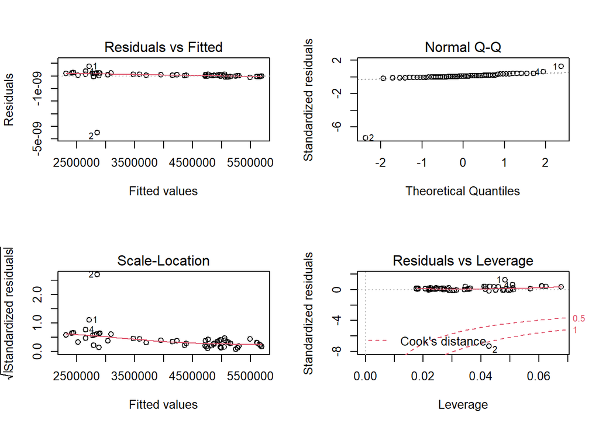

```r
par(mfrow=c(2,2))
plot(Regression_forecasts)
```

```r
par(mfrow=c(1,1))
```

```r
accuracy(Regression_forecasts)
```

```
##                         ME         RMSE          MAE           MPE         MAPE
## Training set -1.633899e-11 6.468879e-10 1.470509e-10 -3.816185e-16 5.347333e-15
##                      MASE
## Training set 1.468872e-16
```

#Regression end

#Comparisons

```r
#naive
naive_accuracy = accuracy(naive_forecast)
naive_accuracy
```

```
##                     ME     RMSE      MAE        MPE     MAPE MASE       ACF1
## Training set -26416.04 228140.4 160037.6 -0.6049683 3.205752    1 0.07203671
```

```r
#Moving Average
SMA_accuracy = accuracy(SMA_forecast)
SMA_accuracy
```

```
##                     ME     RMSE      MAE       MPE     MAPE      MASE      ACF1
## Training set -22583.83 137342.9 108031.7 -0.467046 2.197547 0.9638667 0.5752261
```

```r
#Holt-Winters
HoltWinters_accuracy = accuracy(HoltWinters_forecast)
HoltWinters_accuracy
```

```
##                     ME     RMSE      MAE        MPE     MAPE      MASE
## Training set -26417.51 228141.6 160036.7 -0.6050042 3.205737 0.9999942
##                    ACF1
## Training set 0.07209646
```

```r
#Decomp
ets_accuracy = accuracy(ets_forecast)
ets_accuracy
```

```
##                     ME     RMSE      MAE        MPE     MAPE    MASE       ACF1
## Training set -16612.05 229233.4 163411.2 -0.4272953 3.252019 1.02108 0.03910814
```

```r
#Arima
Arima_accuracy = accuracy(Arima_Forecast)
Arima_accuracy
```

```
##                    ME     RMSE      MAE        MPE     MAPE      MASE
## Training set -25309.6 224174.9 154714.6 -0.5806591 3.098657 0.9667391
##                    ACF1
## Training set 0.06850866
```

```r
#Random Walk
rwf_accuracy = accuracy(rwf_forecast)
rwf_accuracy
```

```
##                     ME     RMSE      MAE        MPE     MAPE MASE       ACF1
## Training set -26416.04 228140.4 160037.6 -0.6049683 3.205752    1 0.07203671
```

```r
#Regression
#Regression_accuracy = accuracy(Regression_forecasts)
#Regression_accuracy

MAPE <- 5
best_accuracy = c()

best_accuracy[1] <- naive_accuracy[MAPE]
best_accuracy[2] <- SMA_accuracy[MAPE]
best_accuracy[3] <- HoltWinters_accuracy[MAPE]
best_accuracy[4] <- ets_accuracy[MAPE]
best_accuracy[5] <- Arima_accuracy[MAPE]
best_accuracy[6] <- rwf_accuracy[MAPE]
#best_accuracy[7] <- Regression_accuracy[5]
```

The matrix

```r
best_accuracy
```

```
## [1] 3.205752 2.197547 3.205737 3.252019 3.098657 3.205752
```

```r
best_accuracy_MAPE = min(best_accuracy)
best_accuracy_MAPE
```

```
## [1] 2.197547
```